# Casual Inference Notebook

# Open part (30% of the grade)

Instead of the glm to calculate the propensity score use any machine learning technique you like such as a regression tree (using rpart), or random forests (randomForest) or neural networks (neuralnet) or another formalism in R to create the propensity score model and to predict the probabilities on such a model. Note that you might need to tweak the model parameters in order to improve it. Compare your results to those you obtained by matching (via the Mahalanobis distance and the propensity score with logistic regression). Which approach do you prefer, and why?

```r
#Installing and loading required packages. Can comment installation lines out after ran once.
# install.packages("randomForest")
# install.packages("caret")
# install.packages("data.table") # reinstall into the user library: the system copy was built for an older R and fails to load (undefined symbol SETLENGTH), which breaks library(caret)
# install.packages("pROC")
# install.packages("CBPS")
# install.packages("ggplot2")
# install.packages("nnet")
# install.packages("corrplot")
# install.packages("survey")
library(CBPS)
library(randomForest)
library(pROC)
library(caret)
library(ggplot2)
library(nnet)
library(corrplot)
library(survey)
```

So far we have compared the Mahalanobis distance and propensity score, with the latter coming in as the strong favourite due to its more comprehensive nature - in the end encoding within it more information than the euclidian distance matching could. However we still have the case of machine learning models. As a group we have decided to try multiple approaches and compare our findings and results between them, looking at different performance metrics and characteristics.

We decided to compare a random forest (RF), a neural network, and covariate balanced propensity score (CBPS) against the standard glm because each represents a genuinely different strategy for estimating the propensity score, and together they probe different weaknesses of the baseline logistic model. The glm assumes a strictly additive relationship, that is linear in the log odds, between covariates and treatment — a strong, potentially wrong assumption we take simply based on faith. Random forest relaxes this assumption by learning through hierarchical thresholds rather than smooth linear terms, closer to how clinical decisions are actually made (a lab value crossing a cutoff, not a proportional risk score), and is able to capture nonlinearities and interactions that the standard glm isn’t able to express. On the otherhand, the neural network gives a different kind of flexibility again; it is a smooth, continuous function approximator that can, in principle, capture arbitrary nonlinear relationships (including interactions) without the discrete splits a tree is restricted to. However, as a result, it is far less interpretable and more sensitive to tuning and preprocessing. Lastly, CBPS (Imai & Ratkovic, 2014) is different from the other two: rather than adding flexibility to the functional form, it keeps the same linear logistic form as the glm but changes directly what the model is optimized for (adds constraints to the loss). This explicitly targets covariate balance in its fitting procedure rather than optimizing predictive likelihood alone. Testing all four side by side lets us separate distinct questions that are usually mixed up: does a more flexible/powerful functional form produce a better propensity score (RF, NN vs. glm), if so, does that produce better balanced covariate groups, and does optimizing directly for the right objective matter more than model flexibility at all (CBPS vs. glm)?

As a first optimization step and comparison between models, we will be finetuning some of the hyperparameters of the RF and NN models to optimize for covariate balance. Very important here is to emphasize the difference between propensity score predictive power and ability to create well-balanced covariate groups. The actual downstream of the propensity scores is to use them to create well balanced groups, not to perfectly classify each patient as treated/not treated. These two goals are related but not the same, and can actively conflict (e.g. a model that predicts treatment too well tends to push scores toward 0 and 1 (near-certain predictions), which destroys overlap/positivity). Maybe a model that is (slightly) overfitted balances better because it moves the propensity scores away from 0/1 and more towards the middle values which we results in more overlap/positivity and better positivity. Therefore, we optimize hyperparameters based on how well they balance the covariates by for each combination of hyperparameters look at the max SMD score, and the number of variables that have below 0.1, between 0.1-0.2 and over 0.2 SMD scores respectively.Note that for the baseline GLM and CBPS models there is no hyperparameter to do, since they essentially have fixed capacity once the formula/functional form is fixed. We will, however, investigate the addition of interaction terms in those two models.

First up is Random Forest. It was primarily chosen due to its simplicity; it is often the classic first choice when ML is in the conversation, it may not have stellar results compared to other methods but it is steady, reliable and relatively interpretable. An interesting concept that came to mind (only a theory at this point, yet to be proven or disproven later in this chapter) is that of continuous vs discrete values. You see our previous two metrics, particularly PS is a continuous value, which works perfectly fine, but in the medical field our decisions are rarely motivated by proportions, but rather by thresholds. A patient is not “62% hypertensive”, but rather a certain blood pressure threshold triggers treatment. Clinical reasoning can be observed as a sequence of cutoff points, which coincidentally is the precise mechanism a decision tree, and by extension - Random Forest, operates with. Whether this structural resemblance translates into better estimates, is what we set out to test in this next section.

```r
rf.data <- rhc.selected[, c(xvars, "treatment.swang")]
rf.data$treatment.swang <- as.factor(rf.data$treatment.swang)
set.seed(42) #standard seed initialization for reproducibility
```

With the base data set up, its time for our hyperparameters and model itself

```r
rf.model <- randomForest(treatment.swang ~ ., data = rf.data, ntree = 500, nodesize = 25)
print(rf.model)
```

```
##
## Call:
##  randomForest(formula = treatment.swang ~ ., data = rf.data, ntree = 500,      nodesize = 25)
##                Type of random forest: classification
##                      Number of trees: 500
## No. of variables tried at each split: 6
##
##         OOB estimate of  error rate: 28.82%
## Confusion matrix:
##      0   1 class.error
## 0 3086 465    0.130949
## 1 1188 996    0.543956
```

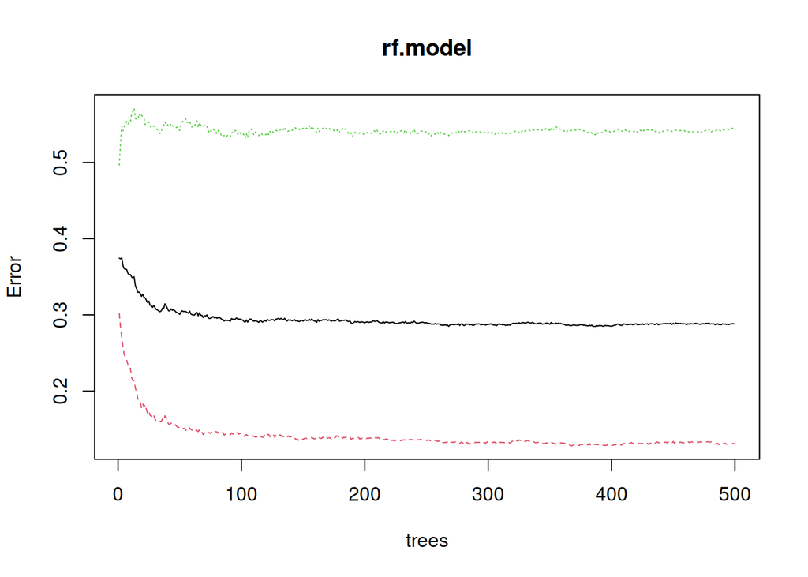

```r
plot(rf.model)
```

The two main dials we have are node size and the number of variables randomly considered as candidates at each split. Node size is the minimum number of patients allowed in a leaf. Its default is 1, meaning a tree keeps splitting until every leaf is pure, so in the limit each leaf is essentially one patient and the tree has memorized the training data. Our starting idea was that this would be bad for a propensity score: a leaf that has memorized a single patient can only ever say “treated” or “not treated”, so we expected the scores to pile up at 0 and 1, which would give infinite logits and destroy the overlap/positivity we need for matching. Forcing larger leaves seemed like the natural fix, since a leaf of 25 patients has to base its vote on a mix of treated and untreated cases rather than on a single one, and we expected that to produce smoother scores and better overlap/positivity. We therefore chose node size = 25 as a starting point, large enough to stop memorization but small enough that the trees can still tell patients apart. Secondly, the default for the number of variables randomly considered as candidates at each split is sqrt(number of predictors), so ~ sqrt(40) which is roughly 6 here. A lower number of possible variables increases randomness and thus decorrelation between trees, which makes them less prone to overfitting but individually have weaker predictive power. Since it brings the propensity scores closer, we suspect better overlap/positivity and consequently better matching, and therefore expect lower mtry values (4/6) to perform better balancing. A larger number of possible variables make the trees more similar to each other and more powerful, but also more prone to overfitting. To test this reasoning and find out which values are optimal for balancing, we test it.

For each of several node size values and number of randomly selected candidate variables we fit a forest, take its propensity scores, and run exactly the same matching and balance check we used for the glm propensity score, so that node size is judged by the thing we actually care about: overlap/positivity in the histograms and balance after matching. Important to note in this analysis is that initially the overlap/positivity checks were done strictly before matching. However, we believe it is better to analyze these results together, since it is not always true that overlap/positivity that seems better visually, also actually gives better balancing. On the other hand, it is also not always true that better SMD scores indicate strictly better balancing, since their might be little overlap/positivity resulting a small number of matched pairs, which is undesirable. Note that we use the number of matched pairs as a proxy for the overlap/positivity of the propensity distributions since less/more overlap/positivity results in fewer/more matched pairs when using a the standard 0.2*STD caliper, respectively. Therefore, we analyzed and reported the SMD scores together with the number of matched pairs, and also visually inspected the overlap/positivity graphs (of which a subset was printed for succinctness).

```r
nodesizes <- c(1, 5, 10, 25, 50, 100)
mtrys <- c(2, 3, 4, 6, 10, 15)  # default for classification is floor(sqrt(n_vars) ~= 6 here, so spread around it but not useful to go lower than 3 since than you get almost entirely random splits in the trees.

ps.by.combo <- list()
rf.comparison <- data.frame()

for (ns in nodesizes) {
  for (mt.val in mtrys) {
    set.seed(42) #Makes the forest's randomness (e.g. bootstrap sampling and feature selection at splits) reproducible
    m <- randomForest(treatment.swang ~ ., data = rf.data, ntree = 300, nodesize = ns, mtry = mt.val) #Fits forest for current nodesize/mtry combo
    ps <- predict(m, type = "prob")[, "1"] #Propensity score = fraction of trees voting "treated"

    key <- paste0("ns", ns, "_mtry", mt.val) #Unique key per combination, e.g. "ns10_mtry6"
    ps.by.combo[[key]] <- ps #Store propensity scores keyed by combo

    # Scores of exactly 0 or 1 have an infinite logit, so we push them up to 0.005 or down to 0.995 to not get an error
    ps.c <- pmin(pmax(ps, 0.005), 0.995)
    # 1:1 greedy matching with Mahalanobis distance on the logit transformed propensity score predicted by the RF, with no replacement and a caliper of      0.2 as before so that we can accurately compare the propensity score calculation method (controlling for other hyperparameters).
    mt <- Match(Tr = rhc.selected$treatment.swang, M = 1, X = logit(ps.c),
                replace = FALSE, Weight = 2, caliper = 0.2)
    md <- rhc.selected[unlist(mt[c("index.treated", "index.control")]), ] #Extract matched data as before
    smd <- ExtractSmd(CreateTableOne(vars = xvars, strata = "treatment.swang", data = md, test = FALSE)) #Calculate SMD scores to check balancing

    # Comparison table; add 1 row of info per hyperparam combo
    rf.comparison <- rbind(rf.comparison, data.frame(
      nodesize       = ns,
      mtry           = mt.val,
      oob.error      = round(tail(m$err.rate[, "OOB"], 1), 3), #Out-of-bound error rate, i.e. held-out validation error for each full RF of 500 trees (similary to classical cross validation). Tells us how accurately predictive model is, but note that we don't want model to predict propensity scores perfectly as 0/1 since then there is bad overlap/positivity in scores.
      extreme.scores = sum(ps < 0.01 | ps > 0.99), # patients with almost certain predictions, don't want this high since leads to unbalanced dataset (bad for positivity)
      matched.pairs  = length(mt$index.treated), # how many subjects succesfully found a caliper satisfying match (fewer = worse overlap/positivity)
      max.smd        = round(max(smd), 3), #maximum found smd (most unbalanced variable)
      worst.var = rownames(smd)[which.max(smd)], #variable with max (worst) smd score
      n.smd.under.0.1 = sum(smd < 0.1), #number of variables well-balanced
      n.smd.0.1.0.2  = sum(smd >= 0.1 & smd <= 0.2), #number of variables in danger zone
      n.smd.over.0.2 = sum(smd > 0.2))) #number of variables not well-balanced
  }
}
# sorted so the best-balancing combos appear first
print("Best balanced variables by max SMD value:")
```

```
## [1] "Best balanced variables by max SMD value:"
```

```r
print(rf.comparison[order(rf.comparison$max.smd), ])
```

```
##    nodesize mtry oob.error extreme.scores matched.pairs max.smd worst.var
## 14       10    3     0.294              9          1659   0.094 Cirrhosis
## 4         1    6     0.285              6          1674   0.102      pot1
## 8         5    3     0.287              6          1664   0.107 Cirrhosis
## 18       10   15     0.295             34          1691   0.108   malighx
## 10        5    6     0.283              9          1658   0.111      dnr1
## 16       10    6     0.289             16          1677   0.111      pot1
## 28       50    6     0.291             91          1684   0.114      pot1
## 6         1   15     0.292             19          1696   0.115  dementhx
## 21       25    4     0.291             26          1675   0.117   transhx
## 23       25   10     0.290             43          1681   0.117      dnr1
## 15       10    4     0.289             15          1656   0.120      pot1
## 12        5   15     0.296             23          1702   0.124      dnr1
## 3         1    4     0.287              6          1668   0.125      hema
## 29       50   10     0.296            120          1699   0.125      dnr1
```

[output cut: 59 more lines]

```r
print("Best balanced variables by number of variables well-balanced:")
```

```
## [1] "Best balanced variables by number of variables well-balanced:"
```

```r
print(rf.comparison[order(-rf.comparison$n.smd.under.0.1), ])
```

```
##    nodesize mtry oob.error extreme.scores matched.pairs max.smd worst.var
## 14       10    3     0.294              9          1659   0.094 Cirrhosis
## 4         1    6     0.285              6          1674   0.102      pot1
## 10        5    6     0.283              9          1658   0.111      dnr1
## 15       10    4     0.289             15          1656   0.120      pot1
## 1         1    2     0.292              6          1675   0.138      pot1
## 2         1    3     0.290              3          1678   0.137      pot1
## 8         5    3     0.287              6          1664   0.107 Cirrhosis
## 16       10    6     0.289             16          1677   0.111      pot1
## 18       10   15     0.295             34          1691   0.108   malighx
## 19       25    2     0.296             28          1664   0.150      pot1
## 31      100    2     0.299            143          1681   0.186      pot1
## 5         1   10     0.291             18          1703   0.133      dnr1
## 7         5    2     0.297             10          1659   0.149      pot1
## 9         5    4     0.292              7          1678   0.127      pot1
```

[output cut: 59 more lines]

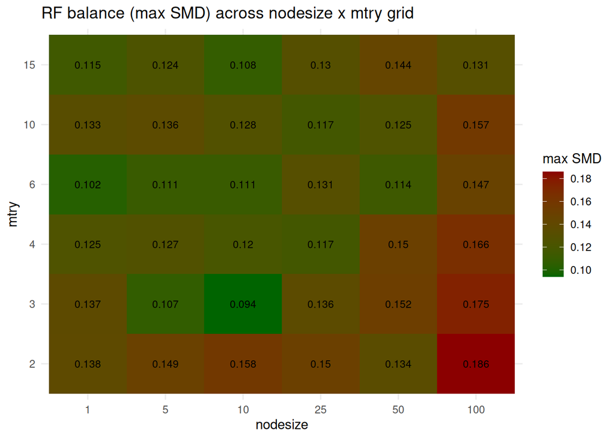

```r
# heatmap of the balance metric to show balance results: number of variables well balanced (SMD < 0.1) and max SMD value.
ggplot(rf.comparison, aes(x = factor(nodesize), y = factor(mtry), fill = max.smd)) +
  geom_tile() +
  geom_text(aes(label = max.smd), size = 3) +
  scale_fill_gradient(low = "darkgreen", high = "darkred") +
  labs(x = "nodesize", y = "mtry", fill = "max SMD",
       title = "RF balance (max SMD) across nodesize x mtry grid") +
  theme_minimal()
```

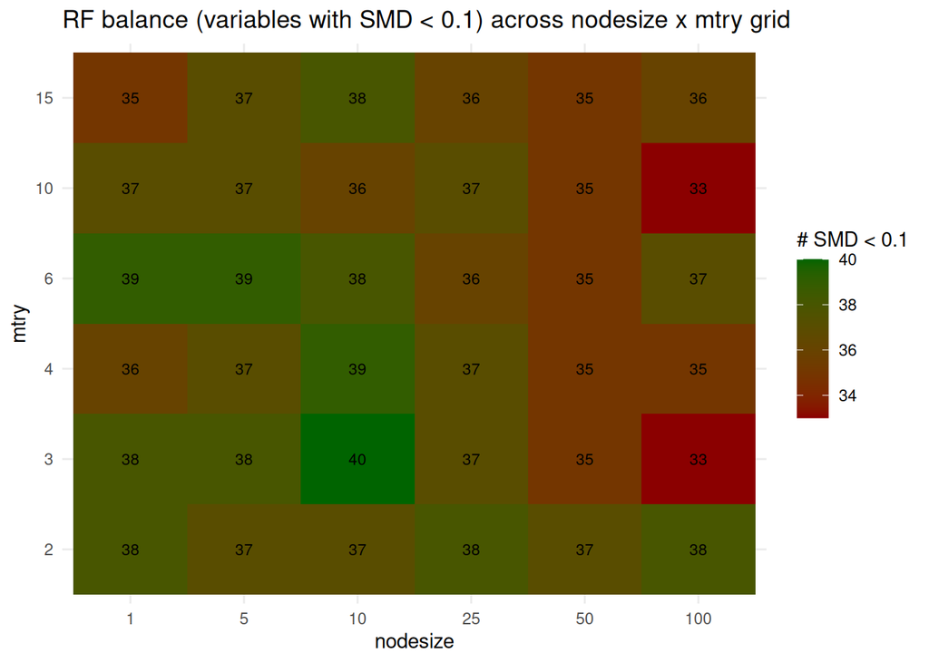

```r
ggplot(rf.comparison, aes(x = factor(nodesize), y = factor(mtry), fill = n.smd.under.0.1)) +
  geom_tile() +
  geom_text(aes(label = n.smd.under.0.1), size = 3) +
  scale_fill_gradient(low = "darkred", high = "darkgreen") +
  labs(x = "nodesize", y = "mtry", fill = "# SMD < 0.1",
       title = "RF balance (variables with SMD < 0.1) across nodesize x mtry grid") +
  theme_minimal()
```

Thus, looking at the table and heatmaps the combinations of nodesize 10 and mtry values 3 gives the best balance (0 variables with SMD above 0.1, max SMD 0.094), and the number of matched pairs is relatively good as well (roughly 1660) so that is what we use for the final random forest model. In the graph below we can observe that this configuration still leeds to good balancing; one hump per group, both spread across roughly 0 to 0.9, and wide overlap/positivity in the middle. This turned out to be practially the best overlap/positivity present in any of the configurations, and have the best balanced groups. Our starting guess of node size 25 and mtry 4/6 was close, but not the best.

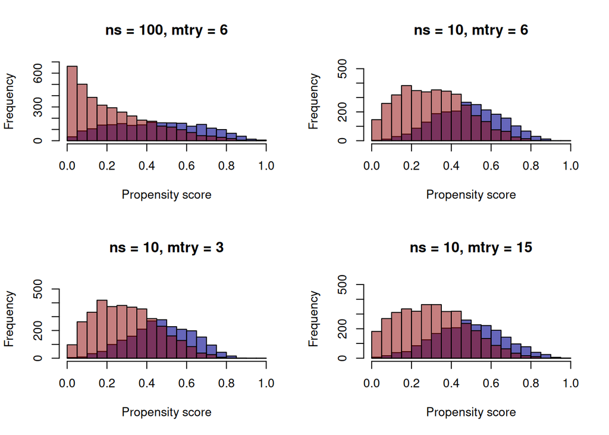

```r
par(mfrow = c(2, 2))

pscore.rf <- pmin(pmax(ps.by.combo[["ns100_mtry6"]], 0.005), 0.995)
brks <- seq(0, 1, 0.05)
ymax <- max(hist(pscore.rf, breaks = brks, plot = FALSE)$counts)
#Plot propensity score frequencies for treated and untreated groups to check for overlap/positivity
hist(pscore.rf[rhc.selected$treatment.swang == 1], breaks = brks, col = rgb(0, 0, 0.55, 0.6),
     xlab = "Propensity score", main = "ns = 100, mtry = 6", ylim = c(0, ymax)) #Use transparansy of 0.6/0.5 to overlap/positivity them nicely
hist(pscore.rf[rhc.selected$treatment.swang == 0], breaks = brks, col = rgb(0.55, 0, 0, 0.5), add = TRUE) #Add to previous histogram to merge them into one overlap/positivityping histogram

pscore.rf <- pmin(pmax(ps.by.combo[["ns10_mtry6"]], 0.005), 0.995)
brks <- seq(0, 1, 0.05)
ymax <- max(hist(pscore.rf, breaks = brks, plot = FALSE)$counts)
#Plot propensity score frequencies for treated and untreated groups to check for overlap/positivity
hist(pscore.rf[rhc.selected$treatment.swang == 1], breaks = brks, col = rgb(0, 0, 0.55, 0.6),
     xlab = "Propensity score", main = "ns = 10, mtry = 6", ylim = c(0, ymax)) #Use transparansy of 0.6/0.5 to overlap/positivity them nicely
hist(pscore.rf[rhc.selected$treatment.swang == 0], breaks = brks, col = rgb(0.55, 0, 0, 0.5), add = TRUE) #Add to previous histogram to merge them into one overlap/positivityping histogram


pscore.rf <- pmin(pmax(ps.by.combo[["ns10_mtry3"]], 0.005), 0.995)
brks <- seq(0, 1, 0.05)
ymax <- max(hist(pscore.rf, breaks = brks, plot = FALSE)$counts)
#Plot propensity score frequencies for treated and untreated groups to check for overlap/positivity
hist(pscore.rf[rhc.selected$treatment.swang == 1], breaks = brks, col = rgb(0, 0, 0.55, 0.6),
     xlab = "Propensity score", main = "ns = 10, mtry = 3", ylim = c(0, ymax)) #Use transparansy of 0.6/0.5 to overlap/positivity them nicely
hist(pscore.rf[rhc.selected$treatment.swang == 0], breaks = brks, col = rgb(0.55, 0, 0, 0.5), add = TRUE) #Add to previous histogram to merge them into one overlap/positivityping histogram

pscore.rf <- pmin(pmax(ps.by.combo[["ns10_mtry15"]], 0.005), 0.995)
brks <- seq(0, 1, 0.05)
ymax <- max(hist(pscore.rf, breaks = brks, plot = FALSE)$counts)
#Plot propensity score frequencies for treated and untreated groups to check for overlap/positivity
hist(pscore.rf[rhc.selected$treatment.swang == 1], breaks = brks, col = rgb(0, 0, 0.55, 0.6),
     xlab = "Propensity score", main = "ns = 10, mtry = 15", ylim = c(0, ymax)) #Use transparansy of 0.6/0.5 to overlap/positivity them nicely
hist(pscore.rf[rhc.selected$treatment.swang == 0], breaks = brks, col = rgb(0.55, 0, 0, 0.5), add = TRUE) #Add to previous histogram to merge them into one overlap/positivityping histogram
```

```r
par(mfrow = c(1, 1))
```

Next up is the neural network. As discussed before, random forests reason through discrete, threshold-based splits, while a a neural network offers the opposite kind of flexibility: a smooth, continuous function of the covariates, fit through gradient-based optimization rather than recursive partitioning. Since this let’s us capture nonlinear relationships and interactions between covariates without being restricted to axis-aligned splits, we expect this to be able to optimize any goal relatively well. However, since this is a very powerful model, we need to ensure careful preprocessing (standardizing numerically encoded inputs) and use regularization to avoid overfitting on a such a tiny dataset. As with random forest, we tune the most important hyperparameters: capacity (hidden layer size) and regularization strength (weight decay). However, again, following our own critique of predictive-accuracy-driven tuning, we select them based on the balance they produce after matching, not on how well they predict treatment assignment. We expect the model configuration that predicts the propensity scores well, but not too well, to have the best results since this will create seperated but still overlapping propensity scores, allowing for good balancing of the groups.

```r
# Preprocessing  (RF didn't need this)
nn.data <- rhc.selected[, c(xvars, "treatment.swang")]
nn.data$treatment.swang <- factor(nn.data$treatment.swang, labels = c("no", "yes"))  # nnet-friendly labels

# model.matrix handles factor -> one-hot expansion automatically and -1 drops intercept column
X.raw <- model.matrix(~ . - 1, data = nn.data[, xvars])

# Standardize (mean 0, sd 1): essential for NN training stability, unlike RF/glm
preproc <- preProcess(X.raw, method = c("center", "scale"))
X.scaled <- predict(preproc, X.raw)

nn.df <- data.frame(X.scaled, treatment.swang = nn.data$treatment.swang)

grid <- expand.grid(size  = c(1, 2, 4, 6, 8, 12),            # number of hidden units
                     decay = c(0, 0.001, 0.01, 0.1, 0.5))  # L2 regularization strength

ps.by.combo.nn <- list()
nn.comparison <- data.frame()

for (i in 1:nrow(grid)) { #loop over grid of hyperparams
  sz <- grid$size[i]; dc <- grid$decay[i]
  set.seed(42) #seed for reproducibility of random intial weights etc.
  # Fit an NN for a max of 300 epochs on this combination of hidden size / decay values. trace = FALSE removes printing at each epoch. linout = FALSE makes it output probability (through sigmoid) rather than raw logit.
  m <- nnet(treatment.swang ~ ., data = nn.df, size = sz, decay = dc,
            trace = FALSE, maxit = 300, linout = FALSE)
  ps <- predict(m, newdata = nn.df, type = "raw")[, 1] #propensity scores for each patient. Note that we just make it predict on full training data and we don't care so much about overfitting, since, as explained before, we just watch propensity scores that balance well, we don't care about if they over or underfit the propensity prediction a bit in the end.

  key <- paste0("size", sz, "_decay", dc)
  ps.by.combo.nn[[key]] <- ps

  # Scores of exactly 0 or 1 have an infinite logit, so we clip them
  ps.c <- pmin(pmax(ps, 0.005), 0.995)
  #Identical matching and SMD calculation steps as before
  mt <- Match(Tr = rhc.selected$treatment.swang, M = 1, X = logit(ps.c),
              replace = FALSE, Weight = 2, caliper = 0.2)
  md <- rhc.selected[unlist(mt[c("index.treated", "index.control")]), ]
  smd <- ExtractSmd(CreateTableOne(vars = xvars, strata = "treatment.swang", data = md, test = FALSE))

  # record hyperparam combination with same metrics as before
  nn.comparison <- rbind(nn.comparison, data.frame(
    size            = sz,
    decay           = dc,
    extreme.scores  = sum(ps < 0.01 | ps > 0.99),
    matched.pairs   = length(mt$index.treated),
    max.smd         = round(max(smd), 3),
    worst.var = rownames(smd)[which.max(smd)],
    n.smd.under.0.1 = sum(smd < 0.1),
    n.smd.0.1.0.2  = sum(smd >= 0.1 & smd <= 0.2),
    n.smd.over.0.2 = sum(smd > 0.2)))
}

print("Best balanced combos by max SMD value:")
```

```
## [1] "Best balanced combos by max SMD value:"
```

```r
print(nn.comparison[order(nn.comparison$max.smd), ])   #ascending: lowest (best) max SMD first
```

```
##    size decay extreme.scores matched.pairs max.smd worst.var n.smd.under.0.1
## 1     1 0.000              0          1735   0.042     hema1              40
## 25    1 0.500              0          1732   0.044   malighx              40
## 7     1 0.001              4          1743   0.048   malighx              40
## 30   12 0.500            242          1209   0.048      seps              40
## 23    8 0.100             69          1383   0.050   renalhx              40
## 24   12 0.100            286          1182   0.051      aps1              40
## 27    4 0.500              4          1552   0.051    scoma1              40
## 21    4 0.100              0          1554   0.052   meanbp1              40
## 13    1 0.010              1          1740   0.055     hema1              40
## 20    2 0.100              0          1666   0.056   immunhx              40
## 8     2 0.001              0          1665   0.057      dnr1              40
## 28    6 0.500             31          1437   0.061     hema1              40
## 29    8 0.500             77          1394   0.061       ARF              40
## 2     2 0.000              0          1657   0.062   wtkilo1              40
```

[output cut: 47 more lines]

```r
print("Best balanced combos by number of variables well-balanced:")
```

```
## [1] "Best balanced combos by number of variables well-balanced:"
```

```r
print(nn.comparison[order(-nn.comparison$n.smd.under.0.1), ])  #descending: most (best) well-balanced vars first
```

```
##    size decay extreme.scores matched.pairs max.smd worst.var n.smd.under.0.1
## 1     1 0.000              0          1735   0.042     hema1              40
## 2     2 0.000              0          1657   0.062   wtkilo1              40
## 3     4 0.000              0          1423   0.075  dementhx              40
## 4     6 0.000             30          1250   0.085  chrpulhx              40
## 7     1 0.001              4          1743   0.048   malighx              40
## 8     2 0.001              0          1665   0.057      dnr1              40
## 9     4 0.001              0          1453   0.095     gastr              40
## 10    6 0.001             28          1288   0.087     wblc1              40
## 13    1 0.010              1          1740   0.055     hema1              40
## 14    2 0.010              0          1671   0.077   wtkilo1              40
## 15    4 0.010              0          1499   0.067      seps              40
## 16    6 0.010             13          1372   0.065      dnr1              40
## 17    8 0.010             97          1363   0.069    scoma1              40
## 18   12 0.010            324          1110   0.092   renalhx              40
```

[output cut: 47 more lines]

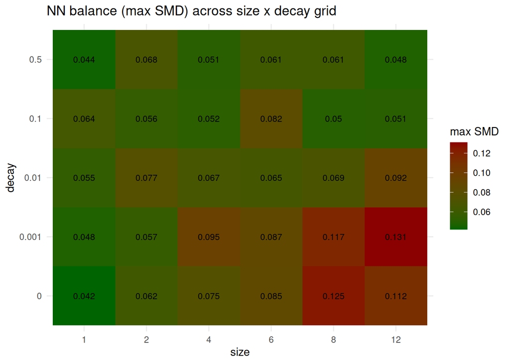

```r
# Again, heatmaps showing the balancing of different hyperparam combinations.
ggplot(nn.comparison, aes(x = factor(size), y = factor(decay), fill = max.smd)) +
  geom_tile() +
  geom_text(aes(label = max.smd), size = 3) +
  scale_fill_gradient(low = "darkgreen", high = "darkred") +
  labs(x = "size", y = "decay", fill = "max SMD",
       title = "NN balance (max SMD) across size x decay grid") +
  theme_minimal()
```

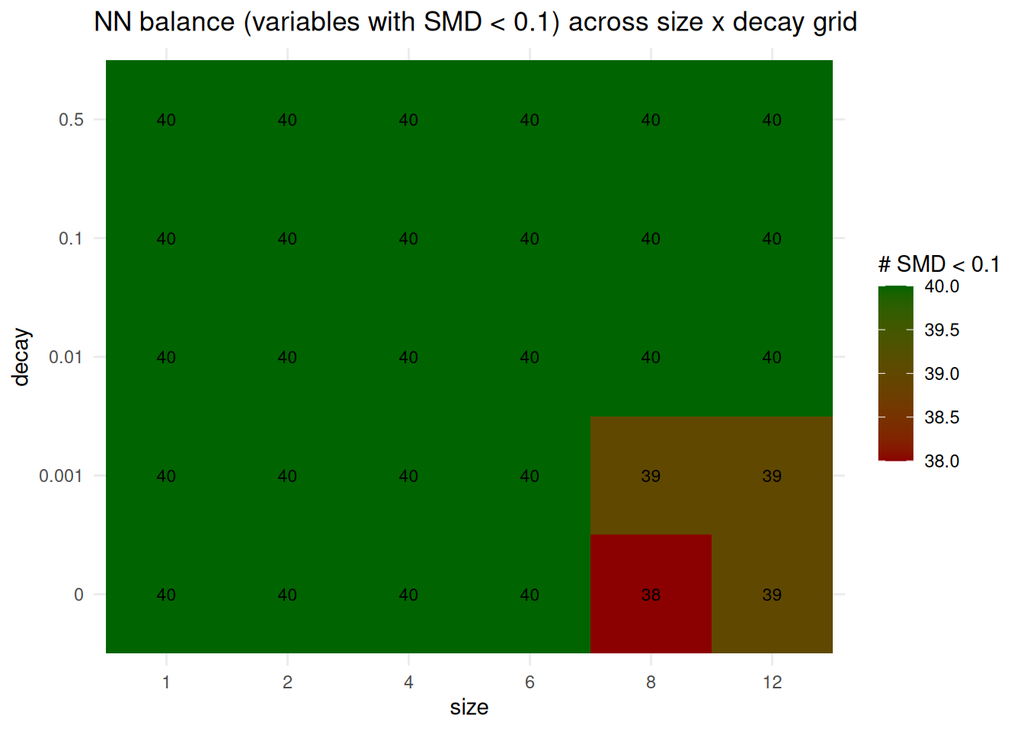

```r
ggplot(nn.comparison, aes(x = factor(size), y = factor(decay), fill = n.smd.under.0.1)) +
  geom_tile() +
  geom_text(aes(label = n.smd.under.0.1), size = 3) +
  scale_fill_gradient(low = "darkred", high = "darkgreen") +
  labs(x = "size", y = "decay", fill = "# SMD < 0.1",
       title = "NN balance (variables with SMD < 0.1) across size x decay grid") +
  theme_minimal()
```

Interestingly, what stands out at first hand are the amazing smd scores. Almost all hyperparameter combinations have all variables with an SMD score below 0.1, and the maximum SMD scores are very below (mostly between 0.04-0.08). This is significantly better than the SMD metrics of the RF models. However we shouldn’t get too excited, since when looking at the number of matched pairs we quicky observe that the number of matched pairs is siginicantly lower (a lot between 900-1400) than in the RF models (1650-1700). This means that as much as half of the treated patients (2184 total) are thrown away during matching, which consequently means a smaller effective sample for the final outcome analysis (t-test, McNemar, logistic regression) , and thus wider confidence intervals, noisier estimates and less power to detect a real effect. Moreover, as explained before, matching estimates the ATT, the effect for the treated population. So, if a caliper throws away too many treated patients, then the estimate no longer represents the effect for all treated patients, but only the effect for the subset of treated patients who happened to be easy to match. That subset may not be representative, e.g. if the dropped patients are systematically different (they likely have more extreme propensity scores, meaning the least/most severely ill), then the ATT estimate is silently shifted toward a different, making the conclusions/finding less generalizable.

[figure not shown]

```r
par(mfrow = c(3, 3))

pscore.nn <- pmin(pmax(ps.by.combo.nn[["size2_decay0.1"]], 0.005), 0.995)
brks <- seq(0, 1, 0.05)
ymax <- max(hist(pscore.nn, breaks = brks, plot = FALSE)$counts)
#Plot propensity score frequencies for treated and untreated groups to check for overlap/positivity
hist(pscore.nn[rhc.selected$treatment.swang == 1], breaks = brks, col = rgb(0, 0, 0.55, 0.6),
     xlab = "Propensity score", main = "size = 2, decay = 0.1", ylim = c(0, ymax)) #Use transparansy of 0.6/0.5 to overlap/positivity them nicely
hist(pscore.nn[rhc.selected$treatment.swang == 0], breaks = brks, col = rgb(0.55, 0, 0, 0.5), add = TRUE) #Add to previous histogram to merge them into one overlap/positivityping histogram

pscore.nn <- pmin(pmax(ps.by.combo.nn[["size2_decay0.001"]], 0.005), 0.995)
brks <- seq(0, 1, 0.05)
ymax <- max(hist(pscore.nn, breaks = brks, plot = FALSE)$counts)
#Plot propensity score frequencies for treated and untreated groups to check for overlap/positivity
hist(pscore.nn[rhc.selected$treatment.swang == 1], breaks = brks, col = rgb(0, 0, 0.55, 0.6),
     xlab = "Propensity score", main = "size = 2, decay = 0.001", ylim = c(0, ymax)) #Use transparansy of 0.6/0.5 to overlap/positivity them nicely
hist(pscore.nn[rhc.selected$treatment.swang == 0], breaks = brks, col = rgb(0.55, 0, 0, 0.5), add = TRUE) #Add to previous histogram to merge them into one overlap/positivityping histogram

pscore.nn <- pmin(pmax(ps.by.combo.nn[["size2_decay0"]], 0.005), 0.995)
brks <- seq(0, 1, 0.05)
ymax <- max(hist(pscore.nn, breaks = brks, plot = FALSE)$counts)
#Plot propensity score frequencies for treated and untreated groups to check for overlap/positivity
hist(pscore.nn[rhc.selected$treatment.swang == 1], breaks = brks, col = rgb(0, 0, 0.55, 0.6),
     xlab = "Propensity score", main = "size = 2, decay = 0", ylim = c(0, ymax)) #Use transparansy of 0.6/0.5 to overlap/positivity them nicely
hist(pscore.nn[rhc.selected$treatment.swang == 0], breaks = brks, col = rgb(0.55, 0, 0, 0.5), add = TRUE) #Add to previous histogram to merge them into one overlap/positivityping histogram

pscore.nn <- pmin(pmax(ps.by.combo.nn[["size6_decay0.1"]], 0.005), 0.995)
brks <- seq(0, 1, 0.05)
ymax <- max(hist(pscore.nn, breaks = brks, plot = FALSE)$counts)
#Plot propensity score frequencies for treated and untreated groups to check for overlap/positivity
hist(pscore.nn[rhc.selected$treatment.swang == 1], breaks = brks, col = rgb(0, 0, 0.55, 0.6),
     xlab = "Propensity score", main = "size = 6, decay = 0.1", ylim = c(0, ymax)) #Use transparansy of 0.6/0.5 to overlap/positivity them nicely
hist(pscore.nn[rhc.selected$treatment.swang == 0], breaks = brks, col = rgb(0.55, 0, 0, 0.5), add = TRUE) #Add to previous histogram to merge them into one overlap/positivityping histogram

pscore.nn <- pmin(pmax(ps.by.combo.nn[["size6_decay0.001"]], 0.005), 0.995)
brks <- seq(0, 1, 0.05)
ymax <- max(hist(pscore.nn, breaks = brks, plot = FALSE)$counts)
#Plot propensity score frequencies for treated and untreated groups to check for overlap/positivity
hist(pscore.nn[rhc.selected$treatment.swang == 1], breaks = brks, col = rgb(0, 0, 0.55, 0.6),
     xlab = "Propensity score", main = "size = 6, decay = 0.100", ylim = c(0, ymax)) #Use transparansy of 0.6/0.5 to overlap/positivity them nicely
hist(pscore.nn[rhc.selected$treatment.swang == 0], breaks = brks, col = rgb(0.55, 0, 0, 0.5), add = TRUE) #Add to previous histogram to merge them into one overlap/positivityping histogram

pscore.nn <- pmin(pmax(ps.by.combo.nn[["size6_decay0"]], 0.005), 0.995)
brks <- seq(0, 1, 0.05)
ymax <- max(hist(pscore.nn, breaks = brks, plot = FALSE)$counts)
#Plot propensity score frequencies for treated and untreated groups to check for overlap/positivity
hist(pscore.nn[rhc.selected$treatment.swang == 1], breaks = brks, col = rgb(0, 0, 0.55, 0.6),
     xlab = "Propensity score", main = "size = 6, decay = 0", ylim = c(0, ymax)) #Use transparansy of 0.6/0.5 to overlap/positivity them nicely
hist(pscore.nn[rhc.selected$treatment.swang == 0], breaks = brks, col = rgb(0.55, 0, 0, 0.5), add = TRUE) #Add to previous histogram to merge them into one overlap/positivityping histogram

pscore.nn <- pmin(pmax(ps.by.combo.nn[["size12_decay0.1"]], 0.005), 0.995)
brks <- seq(0, 1, 0.05)
ymax <- max(hist(pscore.nn, breaks = brks, plot = FALSE)$counts)
#Plot propensity score frequencies for treated and untreated groups to check for overlap/positivity
hist(pscore.nn[rhc.selected$treatment.swang == 1], breaks = brks, col = rgb(0, 0, 0.55, 0.6),
     xlab = "Propensity score", main = "size = 12, decay = 0.1", ylim = c(0, ymax)) #Use transparansy of 0.6/0.5 to overlap/positivity them nicely
hist(pscore.nn[rhc.selected$treatment.swang == 0], breaks = brks, col = rgb(0.55, 0, 0, 0.5), add = TRUE) #Add to previous histogram to merge them into one overlap/positivityping histogram

pscore.nn <- pmin(pmax(ps.by.combo.nn[["size12_decay0.001"]], 0.005), 0.995)
brks <- seq(0, 1, 0.05)
ymax <- max(hist(pscore.nn, breaks = brks, plot = FALSE)$counts)
#Plot propensity score frequencies for treated and untreated groups to check for overlap/positivity
hist(pscore.nn[rhc.selected$treatment.swang == 1], breaks = brks, col = rgb(0, 0, 0.55, 0.6),
     xlab = "Propensity score", main = "size = 12, decay = 0.001", ylim = c(0, ymax)) #Use transparansy of 0.6/0.5 to overlap/positivity them nicely
hist(pscore.nn[rhc.selected$treatment.swang == 0], breaks = brks, col = rgb(0.55, 0, 0, 0.5), add = TRUE) #Add to previous histogram to merge them into one overlap/positivityping histogram

pscore.nn <- pmin(pmax(ps.by.combo.nn[["size12_decay0"]], 0.005), 0.995)
brks <- seq(0, 1, 0.05)
ymax <- max(hist(pscore.nn, breaks = brks, plot = FALSE)$counts)
#Plot propensity score frequencies for treated and untreated groups to check for overlap/positivity
hist(pscore.nn[rhc.selected$treatment.swang == 1], breaks = brks, col = rgb(0, 0, 0.55, 0.6),
     xlab = "Propensity score", main = "size = 12, decay = 0", ylim = c(0, ymax)) #Use transparansy of 0.6/0.5 to overlap/positivity them nicely
hist(pscore.nn[rhc.selected$treatment.swang == 0], breaks = brks, col = rgb(0.55, 0, 0, 0.5), add = TRUE) #Add to previous histogram to merge them into one overlap/positivityping histogram
```

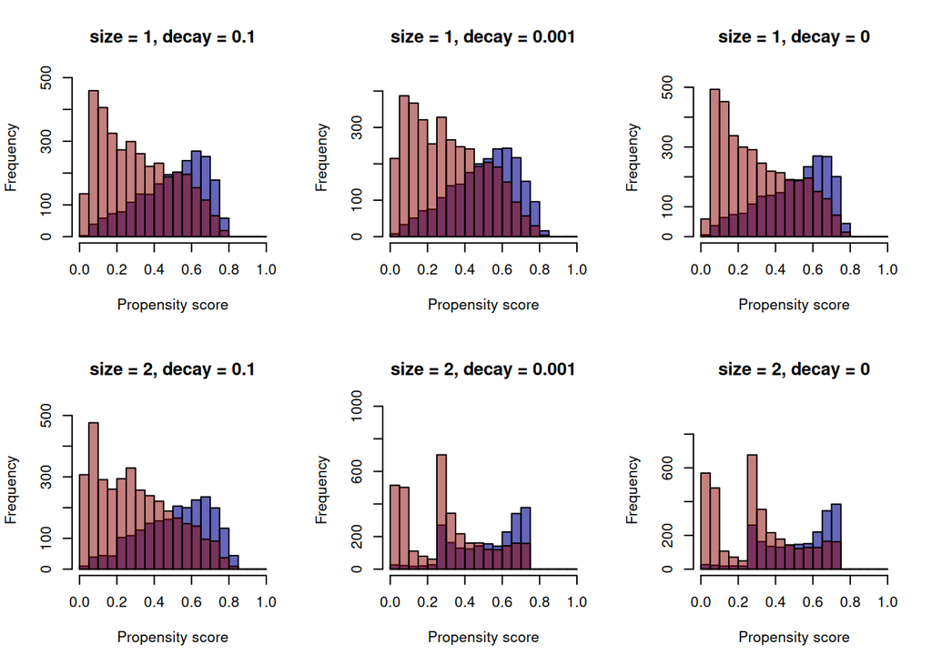

```r
par(mfrow = c(1, 1))


par(mfrow = c(2, 3))
pscore.nn <- pmin(pmax(ps.by.combo.nn[["size1_decay0.1"]], 0.005), 0.995)
brks <- seq(0, 1, 0.05)
ymax <- max(hist(pscore.nn, breaks = brks, plot = FALSE)$counts)
#Plot propensity score frequencies for treated and untreated groups to check for overlap/positivity
hist(pscore.nn[rhc.selected$treatment.swang == 1], breaks = brks, col = rgb(0, 0, 0.55, 0.6),
     xlab = "Propensity score", main = "size = 1, decay = 0.1", ylim = c(0, ymax)) #Use transparansy of 0.6/0.5 to overlap/positivity them nicely
hist(pscore.nn[rhc.selected$treatment.swang == 0], breaks = brks, col = rgb(0.55, 0, 0, 0.5), add = TRUE) #Add to previous histogram to merge them into one overlap/positivityping histogram

pscore.nn <- pmin(pmax(ps.by.combo.nn[["size1_decay0.001"]], 0.005), 0.995)
brks <- seq(0, 1, 0.05)
ymax <- max(hist(pscore.nn, breaks = brks, plot = FALSE)$counts)
#Plot propensity score frequencies for treated and untreated groups to check for overlap/positivity
hist(pscore.nn[rhc.selected$treatment.swang == 1], breaks = brks, col = rgb(0, 0, 0.55, 0.6),
     xlab = "Propensity score", main = "size = 1, decay = 0.001", ylim = c(0, ymax)) #Use transparansy of 0.6/0.5 to overlap/positivity them nicely
hist(pscore.nn[rhc.selected$treatment.swang == 0], breaks = brks, col = rgb(0.55, 0, 0, 0.5), add = TRUE) #Add to previous histogram to merge them into one overlap/positivityping histogram

pscore.nn <- pmin(pmax(ps.by.combo.nn[["size1_decay0"]], 0.005), 0.995)
brks <- seq(0, 1, 0.05)
ymax <- max(hist(pscore.nn, breaks = brks, plot = FALSE)$counts)
#Plot propensity score frequencies for treated and untreated groups to check for overlap/positivity
hist(pscore.nn[rhc.selected$treatment.swang == 1], breaks = brks, col = rgb(0, 0, 0.55, 0.6),
     xlab = "Propensity score", main = "size = 1, decay = 0", ylim = c(0, ymax)) #Use transparansy of 0.6/0.5 to overlap/positivity them nicely
hist(pscore.nn[rhc.selected$treatment.swang == 0], breaks = brks, col = rgb(0.55, 0, 0, 0.5), add = TRUE) #Add to previous histogram to merge them into one overlap/positivityping histogram

pscore.nn <- pmin(pmax(ps.by.combo.nn[["size2_decay0.1"]], 0.005), 0.995)
brks <- seq(0, 1, 0.05)
ymax <- max(hist(pscore.nn, breaks = brks, plot = FALSE)$counts)
#Plot propensity score frequencies for treated and untreated groups to check for overlap/positivity
hist(pscore.nn[rhc.selected$treatment.swang == 1], breaks = brks, col = rgb(0, 0, 0.55, 0.6),
     xlab = "Propensity score", main = "size = 2, decay = 0.1", ylim = c(0, ymax)) #Use transparansy of 0.6/0.5 to overlap/positivity them nicely
hist(pscore.nn[rhc.selected$treatment.swang == 0], breaks = brks, col = rgb(0.55, 0, 0, 0.5), add = TRUE) #Add to previous histogram to merge them into one overlap/positivityping histogram

pscore.nn <- pmin(pmax(ps.by.combo.nn[["size2_decay0.001"]], 0.005), 0.995)
brks <- seq(0, 1, 0.05)
ymax <- max(hist(pscore.nn, breaks = brks, plot = FALSE)$counts)
#Plot propensity score frequencies for treated and untreated groups to check for overlap/positivity
hist(pscore.nn[rhc.selected$treatment.swang == 1], breaks = brks, col = rgb(0, 0, 0.55, 0.6),
     xlab = "Propensity score", main = "size = 2, decay = 0.001", ylim = c(0, ymax)) #Use transparansy of 0.6/0.5 to overlap/positivity them nicely
hist(pscore.nn[rhc.selected$treatment.swang == 0], breaks = brks, col = rgb(0.55, 0, 0, 0.5), add = TRUE) #Add to previous histogram to merge them into one overlap/positivityping histogram

pscore.nn <- pmin(pmax(ps.by.combo.nn[["size2_decay0"]], 0.005), 0.995)
brks <- seq(0, 1, 0.05)
ymax <- max(hist(pscore.nn, breaks = brks, plot = FALSE)$counts)
#Plot propensity score frequencies for treated and untreated groups to check for overlap/positivity
hist(pscore.nn[rhc.selected$treatment.swang == 1], breaks = brks, col = rgb(0, 0, 0.55, 0.6),
     xlab = "Propensity score", main = "size = 2, decay = 0", ylim = c(0, ymax)) #Use transparansy of 0.6/0.5 to overlap/positivity them nicely
hist(pscore.nn[rhc.selected$treatment.swang == 0], breaks = brks, col = rgb(0.55, 0, 0, 0.5), add = TRUE) #Add to previous histogram to merge them into one overlap/positivityping histogram
```

```r
par(mfrow = c(1, 1))
```

Lastly, we get to the CBPS model. As explained before, the actual goal is to create well-balanced treated vs control groups. The regular glm does not directly optimize for this since it simply fits the model to maximize the likelihood of correctly predicting treatment. Balance is never part of the fitting objective and is only measured post-hoc by checking SMD. CBPS (Imai & Ratkovic, 2014) fix this by changing directly what the model is optimizing.

Instead of fitting the propensity model purely by maximum likelihood, the propensity score can be estimated in a way that maximizes a combination of covariate balance as well as the propensity prediction accuracy. CBPS uses the same parametric logistic form as ordinary logistic regression, but chooses the parameters by an augmented set of estimating equations that simultaneously satisfy the usual score/likelihood conditions from logistic regression, but also force the weighted covariate means to be equal between treated and control groups. In other words, balancing constraints are directly incorporated into the equations used to solve for the parameters, rather than only checked afterward. The method, therefore, avoids an iteration between model fitting and balance checking. Note that in the architecture of the CBPS model, we chose to target ATT (average treatment effect on the treated) rather than ATE since in general matching builds counterfactuals for only the treated group so all our estimates in this entire assignment have been estimating ATT and not ATE. Moreover, we use the “exact” method to ensure covariate means are matched exactly between groups.

```r
cbps.model <- CBPS(treatment.swang ~ ., data = rhc.selected[, c(xvars, "treatment.swang")],
                    ATT = 1, method = "exact") #Fit the CBPS model to the data
```

```
## [1] "Finding ATT with T=1 as the treatment.  Set ATT=2 to find ATT with T=0 as the treatment"
```

```r
summary(cbps.model) #significance of coefficients etc. important for variable importance analysis later
```

```
##
## Call:
## CBPS(formula = treatment.swang ~ ., data = rhc.selected[, c(xvars,
##     "treatment.swang")], ATT = 1, method = "exact")
##
## Coefficients:
##                 Estimate  Std. Error z value Pr(>|z|)
## (Intercept)     6.51      0.018      361     0.000    ***
## ARF             -0.211    0.052      -4.07   4.77e-05 ***
## CHF             0.0402    0.0508     0.791   0.429
## Cirrhosis       -1.34     0.0517     -25.9   0.000    ***
## Coma            -0.755    0.0514     -14.7   0.000    ***
## Lung.Cancer     -0.79     0.0367     -21.5   0.000    ***
## MOSF.Malignancy -0.316    0.0542     -5.83   5.5e-09  ***
## cardiohx        0.0843    0.0535     1.57    0.115
## chfhx           -0.0178   0.0573     -0.311  0.756
## dementhx        -0.416    0.0456     -9.13   0.000    ***
## psychhx         -0.431    0.0388     -11.1   0.000    ***
## chrpulhx        -0.178    0.0476     -3.75   0.000179 ***
## renalhx         -0.374    0.0448     -8.35   0.000    ***
## liverhx         -0.179    0.0556     -3.22   0.00129  **
## malighx         -0.296    0.0497     -5.96   2.52e-09 ***
## immunhx         -0.0172   0.0429     -0.4    0.689
## transhx         0.549     0.0423     13      0.000    ***
## age             0.00134   0.0481     0.0278  0.978
## edu             0.0324    0.0417     0.778   0.437
## das2d3pc        0.00889   0.0413     0.215   0.83
## aps1            0.0175    0.0515     0.339   0.734
## scoma1          -0.000885 0.0487     -0.0182 0.985
## meanbp1         -0.00756  0.0453     -0.167  0.867
## wblc1           -0.00125  0.0356     -0.0352 0.972
## temp1           -0.000703 0.0495     -0.0142 0.989
## alb1            -0.116    0.0439     -2.64   0.00836  **
## hema1           -0.0101   0.0417     -0.243  0.808
## bili1           -0.00284  0.0467     -0.0608 0.952
## crea1           0.021     0.0501     0.419   0.675
## pot1            -0.14     0.0453     -3.09   0.00201  **
## paco21          -0.0172   0.0464     -0.371  0.71
## ph1             -0.875    0.0162     -54     0.000    ***
## wtkilo1         0.00748   0.0414     0.181   0.856
## dnr1            -0.676    0.0402     -16.8   0.000    ***
## resp            -0.243    0.0458     -5.29   1.21e-07 ***
## card            0.641     0.0457     14      0.000    ***
## gastr           0.396     0.048      8.24    2.22e-16 ***
## renal           0.218     0.0415     5.26    1.47e-07 ***
## hema            -0.476    0.043      -11.1   0.000    ***
## seps            0.176     0.0421     4.18    2.94e-05 ***
## trauma          1.32      0.0381     34.6    0.000    ***
## ---
## Signif. codes:  0 '***' 0.001 '**' 0.01 '*' 0.05 '.' 0.1 ' ' 1
##
## J - statistic:     0.0128884
## Log-Likelihood:  -3238.854
```

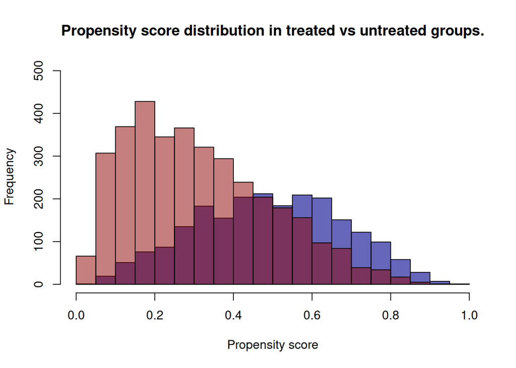

```r
pscore.cbps <- fitted(cbps.model)  # propensity scores
pscore.cbps.c <- pmin(pmax(pscore.cbps, 0.005), 0.995) #clipping as usual

brks <- seq(0, 1, 0.05)
ymax <- max(hist(pscore.cbps, breaks = brks, plot = FALSE)$counts)
#Plot propensity score frequencies for treated and untreated groups to check for overlap/positivity
hist(pscore.cbps[rhc.selected$treatment.swang == 1], breaks = brks, col = rgb(0, 0, 0.55, 0.6),
     xlab = "Propensity score", main = "Propensity score distribution in treated vs untreated groups.", ylim = c(0, ymax)) #Use transparansy of 0.6/0.5 to overlap/positivity them nicely
hist(pscore.cbps[rhc.selected$treatment.swang == 0], breaks = brks, col = rgb(0.55, 0, 0, 0.5), add = TRUE) #Add to previous histogram to merge them into one overlap/positivityping histogram
```

```r
logits.cbps <- logit(pscore.cbps.c)

set.seed(42) #seed for reproducibility if multiple controls are at same distance, as explained before.
# Same matching and SMD calculation steps as fore the general GLM logistic regression model earlier.
psmatch.cbps <- Match(Tr = rhc.selected$treatment.swang, M = 1, X = logits.cbps,
                       replace = FALSE, Weight = 2, caliper = 0.2)
matched_cbps <- rhc.selected[unlist(psmatch.cbps[c("index.treated", "index.control")]), ]
matchedtab1_cbps <- CreateTableOne(vars = xvars, strata = "treatment.swang", data = matched_cbps, test = FALSE)
print(matchedtab1_cbps, smd = TRUE)
```

```
##                              Stratified by treatment.swang
##                               0             1             SMD
##   n                            1733          1733
##   ARF (mean (SD))              0.44 (0.50)   0.44 (0.50)   0.010
##   CHF (mean (SD))              0.10 (0.30)   0.10 (0.30)   0.013
##   Cirrhosis (mean (SD))        0.02 (0.15)   0.03 (0.16)   0.018
##   Coma (mean (SD))             0.05 (0.22)   0.05 (0.21)   0.026
##   Lung.Cancer (mean (SD))      0.00 (0.04)   0.00 (0.05)   0.024
##   MOSF.Malignancy (mean (SD))  0.08 (0.26)   0.08 (0.27)   0.024
##   cardiohx (mean (SD))         0.21 (0.41)   0.20 (0.40)   0.017
##   chfhx (mean (SD))            0.20 (0.40)   0.20 (0.40)   0.004
##   dementhx (mean (SD))         0.08 (0.27)   0.07 (0.26)   0.022
##   psychhx (mean (SD))          0.05 (0.23)   0.05 (0.22)   0.005
##   chrpulhx (mean (SD))         0.16 (0.37)   0.15 (0.36)   0.033
##   renalhx (mean (SD))          0.05 (0.22)   0.05 (0.22)   0.003
##   liverhx (mean (SD))          0.06 (0.24)   0.07 (0.25)   0.026
##   malighx (mean (SD))          0.22 (0.41)   0.22 (0.42)   0.015
##   immunhx (mean (SD))          0.29 (0.45)   0.29 (0.45)   0.010
##   transhx (mean (SD))          0.12 (0.33)   0.12 (0.33)   0.007
##   age (mean (SD))             61.15 (17.23) 60.86 (15.57)  0.017
##   edu (mean (SD))             11.77 (3.11)  11.77 (3.17)   0.001
##   das2d3pc (mean (SD))        20.67 (5.64)  20.55 (5.00)   0.022
##   aps1 (mean (SD))            57.50 (19.24) 57.43 (19.34)  0.003
##   scoma1 (mean (SD))          19.09 (28.97) 18.60 (27.80)  0.017
##   meanbp1 (mean (SD))         73.22 (35.34) 73.00 (35.33)  0.006
##   wblc1 (mean (SD))           15.56 (12.05) 15.98 (12.74)  0.034
##   temp1 (mean (SD))           37.65 (1.88)  37.61 (1.75)   0.021
##   alb1 (mean (SD))             3.04 (0.72)   3.03 (0.95)   0.016
##   hema1 (mean (SD))           31.24 (8.50)  30.78 (7.46)   0.058
##   bili1 (mean (SD))            2.33 (5.02)   2.57 (5.18)   0.048
##   crea1 (mean (SD))            2.30 (2.31)   2.32 (2.00)   0.011
##   pot1 (mean (SD))             4.08 (1.06)   4.04 (1.00)   0.030
##   paco21 (mean (SD))          37.63 (11.43) 37.38 (11.26)  0.022
##   ph1 (mean (SD))              7.39 (0.11)   7.39 (0.11)   0.010
##   wtkilo1 (mean (SD))         71.10 (26.59) 70.72 (27.10)  0.014
##   dnr1 (mean (SD))             0.08 (0.27)   0.08 (0.27)   0.006
##   resp (mean (SD))             0.33 (0.47)   0.33 (0.47)  <0.001
##   card (mean (SD))             0.41 (0.49)   0.39 (0.49)   0.026
##   gastr (mean (SD))            0.18 (0.38)   0.18 (0.39)   0.024
##   renal (mean (SD))            0.06 (0.23)   0.06 (0.24)   0.029
##   hema (mean (SD))             0.06 (0.23)   0.06 (0.24)   0.020
##   seps (mean (SD))             0.21 (0.40)   0.21 (0.41)   0.016
##   trauma (mean (SD))           0.01 (0.10)   0.01 (0.10)  <0.001
```

```r
smd_values_matched_cbps <- ExtractSmd(matchedtab1_cbps)

sprintf("Matched pairs: %d (of %d treated)", length(psmatch.cbps$index.treated), sum(rhc.selected$treatment.swang))
```

```
## [1] "Matched pairs: 1733 (of 2184 treated)"
```

```r
sprintf("Max SMD: %.3f", max(smd_values_matched_cbps))
```

```
## [1] "Max SMD: 0.058"
```

```r
sprintf("SMD < 0.1: %d variables", sum(smd_values_matched_cbps < 0.1))
```

```
## [1] "SMD < 0.1: 40 variables"
```

```r
sprintf("0.1 <= SMD < 0.2: %d variables", sum(smd_values_matched_cbps >= 0.1 & smd_values_matched_cbps < 0.2))
```

```
## [1] "0.1 <= SMD < 0.2: 0 variables"
```

```r
sprintf("SMD > 0.2: %d variables", sum(smd_values_matched_cbps > 0.2))
```

```
## [1] "SMD > 0.2: 0 variables"
```

The results above show promising results. First of all, the overlap/positivity seems okay; both groups have their own slight peak but their is sufficient overlap present across a wide range from 0.1-0.9, which is confirmed by the relatively large number of matches at 1733. Moreover, the SMD balancing metrics are very positive, as all 40 variables scored below 0.1, and the max SMD even is 0.058. Overall, this means that this method, which bakes balancing directly into its optimization equations, indeed succeeds well at balancing the two groups across the covariates, while keeping a good sample size for the downstream effect analysis.

# Now, we compare the number of matched pairs and balancing (through max SMD score, and number of variables below 0.1, between 0.1-0.2 and over 0.2 respecitvely) between each of the 5 methods. Below we report these metrics, as well as their propensity overlap/positivity graphs for the 4 propensity-based methods one more time for convenience.

Now that we have looked at all 5 methods seperately, and chose the best models for the two methods that required hyperparameter optimization (RF & NN). We can compare the balancing performance methods between the different methods. Below the overlap/positivity graphs of the 4 propensity-based methods are shown, as well as the number of matching pairs and SMD metrics for all 5 methods. The intial matching based on the Mahalanobis distance of the covariate directly used no caliper (as per instructions), therefore it matched all treated subjects (2184), which is a plus since it keeps the sample size as large as possible for the downstream final outcome analysis in the next part. However, to obtain comparable results, we performed greedy matching also with the 0.2 caliper (see below), which resulted in 0 matches. This means that not a single treated subject could find a control patient where each of the covariate values were at least 0.2 standardized units apart. This shows that yes it is evident that the greedy matching produces far less good matches compared to the other methods (as we will also see in the SMD metrics next). However, it might also suggest that the default 0.2 standardized units caliper might be a too strict metric in a high number of dimensions. It requires the mean of each of the 40 variables to be less than 0.2 standardized units away, possibly throwing away good potential matches that might be just too far away in one or a couple of the 40 dimensions. We will return to this and analyze it later when doing a caliper sensitivity analysis. Looking at the other methods in the table, we see much better number of matches. The GLM, NN and CPS all have a roughly equal number of matches (1730-1740), while the RF has a (slightly) lower number of matches (1659), of the total 2184 treated patients. When looking at the overlap graphs, we do see that the NN has a bit worse overlap than the rest, which can be explained by its enormous power and flexibility to produce very accurate propensity predicitions as we discussed before. However, overall the overlap/positivity assumption seems valid in all four methods. Lastly, when looking at the SMD results, we clearly observe that the greedy matching performs worst, with a max SMD of 0.501, only 24 variables with a score below 0.1, and 7 variables with a score above 0.2, indicating that the groups are highly inbalanced on those covariates. The other 4 methods score roughly similar, each having a max SMD score below 0.1 (implyinh that all 40 variables are below 0.1), with the original GLM method doing as low as 0.035. Based on these results, there does not seem to be a clear winner. However, given that they perform similarly, we prefer the original GLM implementation, as the more simplistic model is more interpretable, as we can more directly interpret it’s coefficients to see which variables contributed in what way to the predictions, allowing for better explainability of the model. The original clearly greedy matching model clearly underperforms in all aspects to the other models, as discussed before.

```r
#Perform greedy matching also with the same caliper for comparable results
greedymatch2 <- Match(Tr = rhc.selected$treatment.swang, M = 1, X = as.matrix(rhc.selected[xvars]),
                      replace = FALSE, Weight = 2, caliper=0.2)
if (!is.list(greedymatch2) || is.null(greedymatch2$index.treated)) { #safety check to see if any matches at all
  print("No valid matches found with greedy matching with the 0.2 caliper.")
} else {
  sprintf("Greedy matching has %d matches when also using a 0.2 caliper", length(greedymatch2$index.treated))
}
```

```
## [1] "No valid matches found with greedy matching with the 0.2 caliper."
```

```r
# Pull the RF and NN SMD summary values from their comparison tables
rf.row <- rf.comparison[rf.comparison$nodesize == 10 & rf.comparison$mtry == 3, ]
nn.row <- nn.comparison[nn.comparison$size == 1 & nn.comparison$decay == 0.01, ]

sprintf("Matched pairs: Mahalanobis (no caliper) = %d, glm PS = %d, RF PS = %d, NN PS = %d, CBPS PS = %d (of %d treated)",
        length(greedymatch$index.treated), length(psmatch$index.treated),
        rf.row$matched.pairs,nn.row$matched.pairs, length(psmatch.cbps$index.treated), sum(rhc.selected$treatment.swang))
```

```
## [1] "Matched pairs: Mahalanobis (no caliper) = 2184, glm PS = 1734, RF PS = 1659, NN PS = 1740, CBPS PS = 1733 (of 2184 treated)"
```

```r
sprintf("Max SMD: Mahalanobis (no caliper) = %.3f, glm PS = %.3f, RF PS = %.3f, NN PS = %.3f, CBPS PS = %.3f",
        max(smd_values_matched), max(smd_values_matched_ps), rf.row$max.smd, nn.row$max.smd, max(smd_values_matched_cbps))
```

```
## [1] "Max SMD: Mahalanobis (no caliper) = 0.501, glm PS = 0.035, RF PS = 0.094, NN PS = 0.055, CBPS PS = 0.058"
```

```r
sprintf("SMD < 0.1: Mahalanobis (no caliper) = %d, glm PS = %d, RF PS = %d, NN PS = %d, CBPS PS = %d",
        sum(smd_values_matched < 0.1), sum(smd_values_matched_ps < 0.1), rf.row$n.smd.under.0.1, nn.row$n.smd.under.0.1, sum(smd_values_matched_cbps < 0.1))
```

```
## [1] "SMD < 0.1: Mahalanobis (no caliper) = 24, glm PS = 40, RF PS = 40, NN PS = 40, CBPS PS = 40"
```

```r
sprintf("0.1 <= SMD <= 0.2: Mahalanobis  (no caliper)= %d, glm PS = %d, RF PS = %d, NN PS = %d, CBPS PS = %d",
        sum(smd_values_matched >= 0.1 & smd_values_matched <= 0.2), sum(smd_values_matched_ps >= 0.1 & smd_values_matched_ps <= 0.2), rf.row$n.smd.0.1.0.2, nn.row$n.smd.0.1.0.2, sum(smd_values_matched_cbps >= 0.1 & smd_values_matched_cbps <= 0.2))
```

```
## [1] "0.1 <= SMD <= 0.2: Mahalanobis  (no caliper)= 9, glm PS = 0, RF PS = 0, NN PS = 0, CBPS PS = 0"
```

```r
sprintf("SMD > 0.2: Mahalanobis (no caliper) = %d, glm PS = %d, RF PS = %d, NN PS = %d, CBPS PS = %d",
        sum(smd_values_matched > 0.2), sum(smd_values_matched_ps > 0.2),
        rf.row$n.smd.over.0.2, nn.row$n.smd.over.0.2, sum(smd_values_matched_cbps > 0.2))
```

```
## [1] "SMD > 0.2: Mahalanobis (no caliper) = 7, glm PS = 0, RF PS = 0, NN PS = 0, CBPS PS = 0"
```

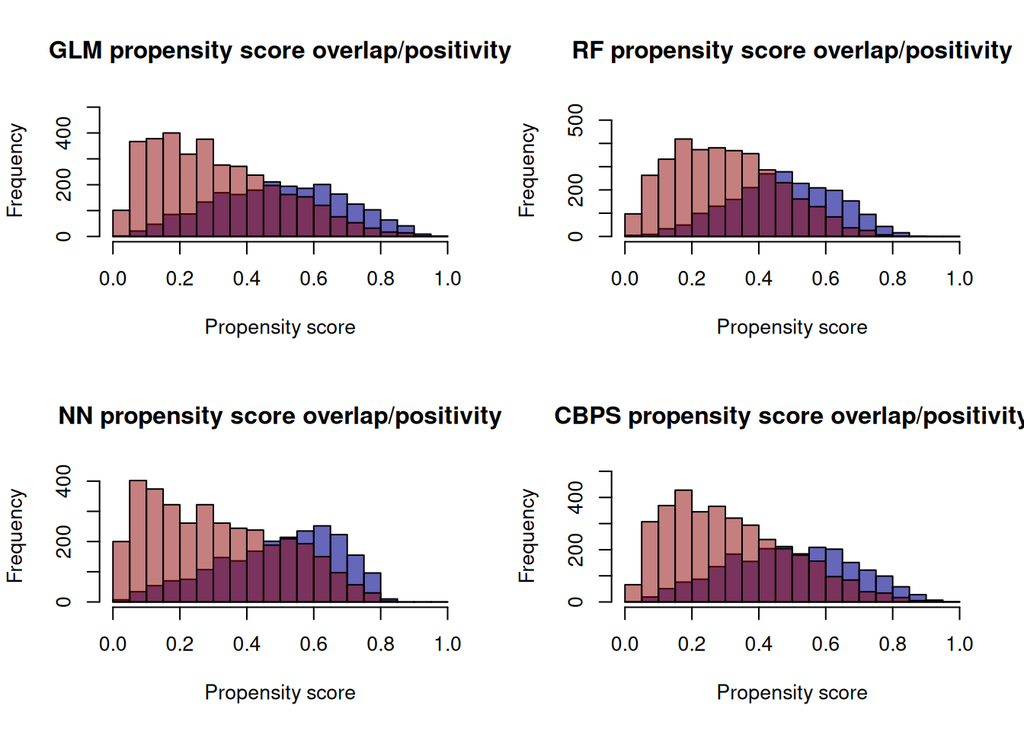

```r
pscore.rf <- pmin(pmax(ps.by.combo[["ns10_mtry3"]], 0.005), 0.995)
pscore.nn <- pmin(pmax(ps.by.combo.nn[["size1_decay0.01"]], 0.005), 0.995)

par(mfrow = c(2, 2))
pscores.list <- list(
  "GLM"  = pscore,
  "RF"   = pscore.rf,
  "NN"   = pscore.nn,
  "CBPS" = pscore.cbps
)

brks <- seq(0, 1, 0.05)

for (name in names(pscores.list)) {
  ps <- pscores.list[[name]]
  ymax <- max(hist(ps, breaks = brks, plot = FALSE)$counts)

  hist(ps[rhc.selected$treatment.swang == 1], breaks = brks, col = rgb(0, 0, 0.55, 0.6),
       xlab = "Propensity score", main = paste(name, "propensity score overlap/positivity"), ylim = c(0, ymax))
  hist(ps[rhc.selected$treatment.swang == 0], breaks = brks, col = rgb(0.55, 0, 0, 0.5), add = TRUE)
}
```

```r
par(mfrow = c(1, 1))
```

# Here we define our best performing model for each of the 2 finetuned methods and get their corresponding matched sets, so we can then continue with the rest of the analysis to see whether treatment significantly explains outcomes for each of the methods.

```r
# Create matched set for final random forest (node size = 10, mtry = 3 , 300 trees) for further downstream analysis.
set.seed(42)
# Final, best balancing Random Forest:
rf.model  <- randomForest(treatment.swang ~ ., data = rf.data, ntree = 300, nodesize = 10, mtry = 3, importance = TRUE)
pscore.rf <- predict(rf.model, type = "prob")[, "1"]
psmatch.rf <- Match(Tr = rhc.selected$treatment.swang, M = 1, X = logit(pmin(pmax(pscore.rf, 0.005), 0.995)),
                    replace = FALSE, Weight = 2, caliper = 0.2)
matched_rf <- rhc.selected[unlist(psmatch.rf[c("index.treated", "index.control")]), ]


# Create matched set for final neural network (weight decay = 0.01, hidden size = 1) for further downstream analysis.
# Final, best balancing Neural Network:
m <- nnet(treatment.swang ~ ., data = nn.df, size = 1, decay = 0.01,
          trace = FALSE, maxit = 300, linout = FALSE)
pscore.nn <- predict(m, newdata = nn.df, type = "raw")[, 1]
psmatch.nn <- Match(Tr = rhc.selected$treatment.swang, M = 1, X = logit(pmin(pmax(pscore.nn, 0.005), 0.995)), replace = FALSE, Weight = 2, caliper = 0.2)
matched_nn <- rhc.selected[unlist(psmatch.nn[c("index.treated", "index.control")]), ]
```

#Next, we perform the downstream outcome statistical analysis for each of the three new methods. Note that even though we prefer the original GLM model for its simplicity and interpretibility, we perform the analysis for all three models for comparison anyways, since the balancing performance was very similar.

```r
print("===================================================")
```

```
## [1] "==================================================="
```

```r
set.seed(42) #For reproducibility of results
# First for the RF:
print("For the RF:")
```

```
## [1] "For the RF:"
```

```r
y_trt.rf <- matched_rf$outcome.died[matched_rf$treatment.swang == 1]
y_con.rf <- matched_rf$outcome.died[matched_rf$treatment.swang == 0]

t.test(y_trt.rf - y_con.rf)                 # paired t-test, indicative only
```

```
##
##  One Sample t-test
##
## data:  y_trt.rf - y_con.rf
## t = 2.2233, df = 1659, p-value = 0.02633
## alternative hypothesis: true mean is not equal to 0
## 95 percent confidence interval:
##  0.004258347 0.068030809
## sample estimates:
##  mean of x
## 0.03614458
```

```r
table(y_trt.rf, y_con.rf)
```

```
##         y_con.rf
## y_trt.rf   0   1
##        0 192 335
##        1 395 738
```

```r
mcnemar.test(table(y_trt.rf, y_con.rf))     # correct test for paired binary data
```

```
##
##  McNemar's Chi-squared test with continuity correction
##
## data:  table(y_trt.rf, y_con.rf)
## McNemar's chi-squared = 4.7685, df = 1, p-value = 0.02899
```

```r
gmodel5 <- glm(outcome.died ~ treatment.swang, family = binomial, data = matched_rf)
summary(gmodel5)
```

```
##
## Call:
## glm(formula = outcome.died ~ treatment.swang, family = binomial,
##     data = matched_rf)
##
## Coefficients:
##                 Estimate Std. Error z value Pr(>|z|)
## (Intercept)      0.60319    0.05134  11.749   <2e-16 ***
## treatment.swang  0.16223    0.07359   2.205   0.0275 *
## ---
## Signif. codes:  0 '***' 0.001 '**' 0.01 '*' 0.05 '.' 0.1 ' ' 1
##
## (Dispersion parameter for binomial family taken to be 1)
##
##     Null deviance: 4236.5  on 3319  degrees of freedom
## Residual deviance: 4231.7  on 3318  degrees of freedom
## AIC: 4235.7
##
## Number of Fisher Scoring iterations: 4
```

```r
# Doubly robust: adjust for the least well balanced variable
worst.rf <- rf.row$worst.var
gmodel6 <- glm(as.formula(paste("outcome.died ~ treatment.swang +", worst.rf)), family = binomial, data = matched_rf)
summary(gmodel6)
```

```
##
## Call:
## glm(formula = as.formula(paste("outcome.died ~ treatment.swang +",
##     worst.rf)), family = binomial, data = matched_rf)
##
## Coefficients:
##                 Estimate Std. Error z value Pr(>|z|)
## (Intercept)      0.58412    0.05181  11.274   <2e-16 ***
## treatment.swang  0.16764    0.07369   2.275   0.0229 *
## Cirrhosis        0.63318    0.24955   2.537   0.0112 *
## ---
## Signif. codes:  0 '***' 0.001 '**' 0.01 '*' 0.05 '.' 0.1 ' ' 1
##
## (Dispersion parameter for binomial family taken to be 1)
##
##     Null deviance: 4236.5  on 3319  degrees of freedom
## Residual deviance: 4224.5  on 3317  degrees of freedom
## AIC: 4230.5
##
## Number of Fisher Scoring iterations: 4
```

```r
sprintf("Odds ratio for treatment: %.4f", exp(coef(gmodel5)["treatment.swang"]))
```

```
## [1] "Odds ratio for treatment: 1.1761"
```

```r
sprintf("Odds ratio for treatment after adjusting for %s: %.4f", worst.rf, exp(coef(gmodel6)["treatment.swang"]))
```

```
## [1] "Odds ratio for treatment after adjusting for Cirrhosis: 1.1825"
```

```r
effects <- data.frame(
  method      = c("Mahalanobis", "PS (glm)", "PS (random forest)"),
  pairs       = c(length(greedymatch$index.treated), length(psmatch$index.treated), length(psmatch.rf$index.treated)),
  mean.diff   = c(mean(y_trt - y_con), mean(y_trt.ps - y_con.ps), mean(y_trt.rf - y_con.rf)),
  OR          = exp(c(coef(gmodel1)["treatment.swang"], coef(gmodel3)["treatment.swang"], coef(gmodel5)["treatment.swang"])),
  OR.adjusted = exp(c(coef(gmodel2)["treatment.swang"], coef(gmodel4)["treatment.swang"], coef(gmodel6)["treatment.swang"])))
#print(effects, digits = 4, row.names = FALSE)


# Next, for the neural network:
print("For the NN:")
```

```
## [1] "For the NN:"
```

```r
y_trt.nn <- matched_nn$outcome.died[matched_nn$treatment.swang == 1]
y_con.nn <- matched_nn$outcome.died[matched_nn$treatment.swang == 0]

t.test(y_trt.nn - y_con.nn)
```

```
##
##  One Sample t-test
##
## data:  y_trt.nn - y_con.nn
## t = 3.7425, df = 1739, p-value = 0.0001881
## alternative hypothesis: true mean is not equal to 0
## 95 percent confidence interval:
##  0.02844635 0.09109388
## sample estimates:
##  mean of x
## 0.05977011
```

```r
mcnemar.test(table(y_trt.nn, y_con.nn))
```

```
##
##  McNemar's Chi-squared test with continuity correction
##
## data:  table(y_trt.nn, y_con.nn)
## McNemar's chi-squared = 13.636, df = 1, p-value = 0.0002219
```

```r
gmodel7 <- glm(outcome.died ~ treatment.swang, family = binomial, data = matched_nn)
summary(gmodel7)
```

```
##
## Call:
## glm(formula = outcome.died ~ treatment.swang, family = binomial,
##     data = matched_nn)
##
## Coefficients:
##                 Estimate Std. Error z value Pr(>|z|)
## (Intercept)      0.50470    0.04948  10.200  < 2e-16 ***
## treatment.swang  0.26443    0.07144   3.701 0.000215 ***
## ---
## Signif. codes:  0 '***' 0.001 '**' 0.01 '*' 0.05 '.' 0.1 ' ' 1
##
## (Dispersion parameter for binomial family taken to be 1)
##
##     Null deviance: 4491.2  on 3479  degrees of freedom
## Residual deviance: 4477.5  on 3478  degrees of freedom
## AIC: 4481.5
##
## Number of Fisher Scoring iterations: 4
```

```r
worst.nn <- nn.row$worst.var
gmodel8 <- glm(as.formula(paste("outcome.died ~ treatment.swang +", worst.nn)), family = binomial, data = matched_nn)
summary(gmodel8)
```

```
##
## Call:
## glm(formula = as.formula(paste("outcome.died ~ treatment.swang +",
##     worst.nn)), family = binomial, data = matched_nn)
##
## Coefficients:
##                  Estimate Std. Error z value Pr(>|z|)
## (Intercept)      1.106706   0.148343   7.460 8.62e-14 ***
## treatment.swang  0.273711   0.071676   3.819 0.000134 ***
## hema1           -0.019651   0.004542  -4.326 1.52e-05 ***
## ---
## Signif. codes:  0 '***' 0.001 '**' 0.01 '*' 0.05 '.' 0.1 ' ' 1
##
## (Dispersion parameter for binomial family taken to be 1)
##
##     Null deviance: 4491.2  on 3479  degrees of freedom
## Residual deviance: 4458.8  on 3477  degrees of freedom
## AIC: 4464.8
##
## Number of Fisher Scoring iterations: 4
```

```r
sprintf("OR (unadjusted): %.4f", exp(coef(gmodel7)["treatment.swang"]))
```

```
## [1] "OR (unadjusted): 1.3027"
```

```r
sprintf("OR (adjusted for %s): %.4f", worst.nn, exp(coef(gmodel8)["treatment.swang"]))
```

```
## [1] "OR (adjusted for hema1): 1.3148"
```

```r
effects <- rbind(effects, data.frame(
  method       = "PS (neural net)",
  pairs        = length(psmatch.nn$index.treated),
  mean.diff    = mean(y_trt.nn - y_con.nn),
  OR           = exp(coef(gmodel7)["treatment.swang"]),
  OR.adjusted  = exp(coef(gmodel8)["treatment.swang"])))
#print(effects, digits = 4, row.names = FALSE)

#Lastly, for the CPBS model:
print("For the CBPS:")
```

```
## [1] "For the CBPS:"
```

```r
y_trt.cbps <- matched_cbps$outcome.died[matched_cbps$treatment.swang == 1]
y_con.cbps <- matched_cbps$outcome.died[matched_cbps$treatment.swang == 0]

t.test(y_trt.cbps - y_con.cbps)
```

```
##
##  One Sample t-test
##
## data:  y_trt.cbps - y_con.cbps
## t = 4.1076, df = 1732, p-value = 4.184e-05
## alternative hypothesis: true mean is not equal to 0
## 95 percent confidence interval:
##  0.03467334 0.09804449
## sample estimates:
##  mean of x
## 0.06635892
```

```r
mcnemar.test(table(y_trt.cbps, y_con.cbps))
```

```
##
##  McNemar's Chi-squared test with continuity correction
##
## data:  table(y_trt.cbps, y_con.cbps)
## McNemar's chi-squared = 16.43, df = 1, p-value = 5.048e-05
```

```r
gmodel9 <- glm(outcome.died ~ treatment.swang, family = binomial, data = matched_cbps)
summary(gmodel9)
```

```
##
## Call:
## glm(formula = outcome.died ~ treatment.swang, family = binomial,
##     data = matched_cbps)
##
## Coefficients:
##                 Estimate Std. Error z value Pr(>|z|)
## (Intercept)      0.47132    0.04938   9.544  < 2e-16 ***
## treatment.swang  0.29191    0.07141   4.088 4.36e-05 ***
## ---
## Signif. codes:  0 '***' 0.001 '**' 0.01 '*' 0.05 '.' 0.1 ' ' 1
##
## (Dispersion parameter for binomial family taken to be 1)
##
##     Null deviance: 4492.9  on 3465  degrees of freedom
## Residual deviance: 4476.1  on 3464  degrees of freedom
## AIC: 4480.1
##
## Number of Fisher Scoring iterations: 4
```

```r
worst.cbps <- rownames(smd_values_matched_cbps)[which.max(smd_values_matched_cbps)]
gmodel10 <- glm(as.formula(paste("outcome.died ~ treatment.swang +", worst.cbps)), family = binomial, data = matched_cbps)
summary(gmodel10)
```

```
##
## Call:
## glm(formula = as.formula(paste("outcome.died ~ treatment.swang +",
##     worst.cbps)), family = binomial, data = matched_cbps)
##
## Coefficients:
##                  Estimate Std. Error z value Pr(>|z|)
## (Intercept)      1.198798   0.148229   8.087 6.09e-16 ***
## treatment.swang  0.282135   0.071716   3.934 8.35e-05 ***
## hema1           -0.023153   0.004423  -5.235 1.65e-07 ***
## ---
## Signif. codes:  0 '***' 0.001 '**' 0.01 '*' 0.05 '.' 0.1 ' ' 1
##
## (Dispersion parameter for binomial family taken to be 1)
##
##     Null deviance: 4492.9  on 3465  degrees of freedom
## Residual deviance: 4448.7  on 3463  degrees of freedom
## AIC: 4454.7
##
## Number of Fisher Scoring iterations: 4
```

```r
sprintf("OR (unadjusted): %.4f", exp(coef(gmodel9)["treatment.swang"]))
```

```
## [1] "OR (unadjusted): 1.3390"
```

```r
sprintf("OR (adjusted for %s): %.4f", worst.cbps, exp(coef(gmodel10)["treatment.swang"]))
```

```
## [1] "OR (adjusted for hema1): 1.3260"
```

```r
effects <- rbind(effects, data.frame(
  method       = "CBPS",
  pairs        = length(psmatch.cbps$index.treated),
  mean.diff    = mean(y_trt.cbps - y_con.cbps),
  OR           = exp(coef(gmodel9)["treatment.swang"]),
  OR.adjusted  = exp(coef(gmodel10)["treatment.swang"])))
print(effects, digits = 4, row.names = FALSE)
```

```
##              method pairs mean.diff    OR OR.adjusted
##         Mahalanobis  2184   0.09112 1.484       1.220
##            PS (glm)  1734   0.06055 1.305       1.311
##  PS (random forest)  1660   0.03614 1.176       1.183
##     PS (neural net)  1740   0.05977 1.303       1.315
##                CBPS  1733   0.06636 1.339       1.326
```

```r
print("===================================================")
```

```
## [1] "==================================================="
```

# Next, since the 4 propensity models balance similarly well, we want to try and dive a little bit deeper into why this is the case. Do they balance similarly well because they converge on the same distribution of propensity scores? Or do they each get different propensity scores but do the different scores happen to balance simiarly well. As stated at the start, we have no real interest in the propensity scores themselves, only their usage as a balancing tool, so probing this can help us understand the balancing mechanism better.

```r
pscores.df <- data.frame(
  glm  = pscore,
  rf   = pscore.rf,
  nn   = pscore.nn,
  cbps = pscore.cbps
)
cor.matrix.pearson <- cor(pscores.df) #Perform Pearson (linear) correlation
cor.matrix.spearman <- cor(pscores.df, method = "spearman") #Perform Spearman (rank) correlation to check for relative ordering and not just numeric scale.

print(cor.matrix.pearson)
```

```
##            glm        rf        nn      cbps
## glm  1.0000000 0.8319820 0.9924897 0.9949170
## rf   0.8319820 1.0000000 0.8357264 0.8260279
## nn   0.9924897 0.8357264 1.0000000 0.9827090
## cbps 0.9949170 0.8260279 0.9827090 1.0000000
```

```r
print(cor.matrix.spearman)
```

```
##            glm        rf        nn      cbps
## glm  1.0000000 0.8391802 0.9979366 0.9950413
## rf   0.8391802 1.0000000 0.8406892 0.8314638
## nn   0.9979366 0.8406892 1.0000000 0.9882585
## cbps 0.9950413 0.8314638 0.9882585 1.0000000
```

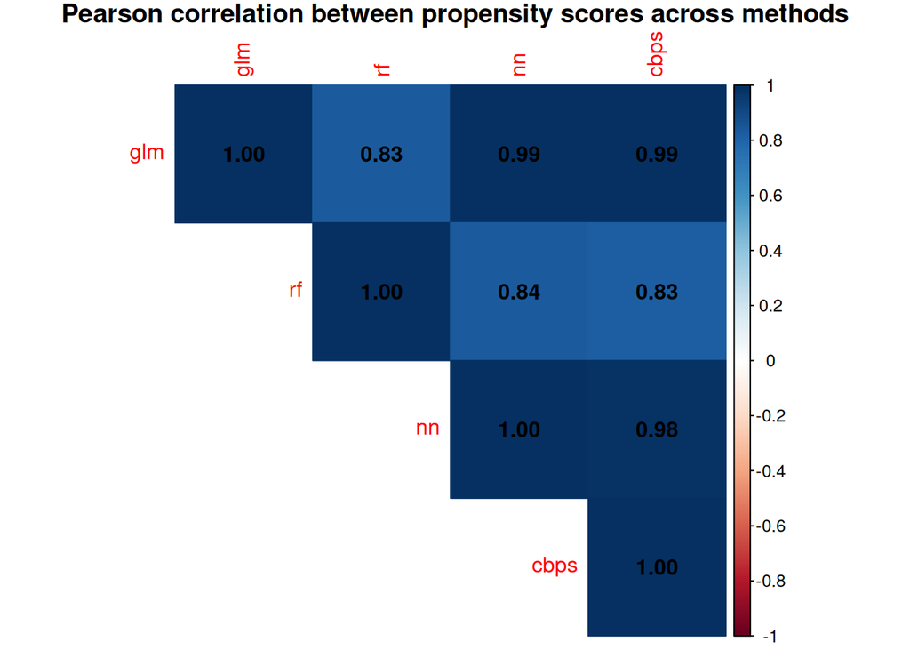

```r
corrplot(cor.matrix.pearson, method = "color", type = "upper", addCoef.col = "black",
         title = "Pearson correlation between propensity scores across methods", mar = c(0,0,1,0))
```

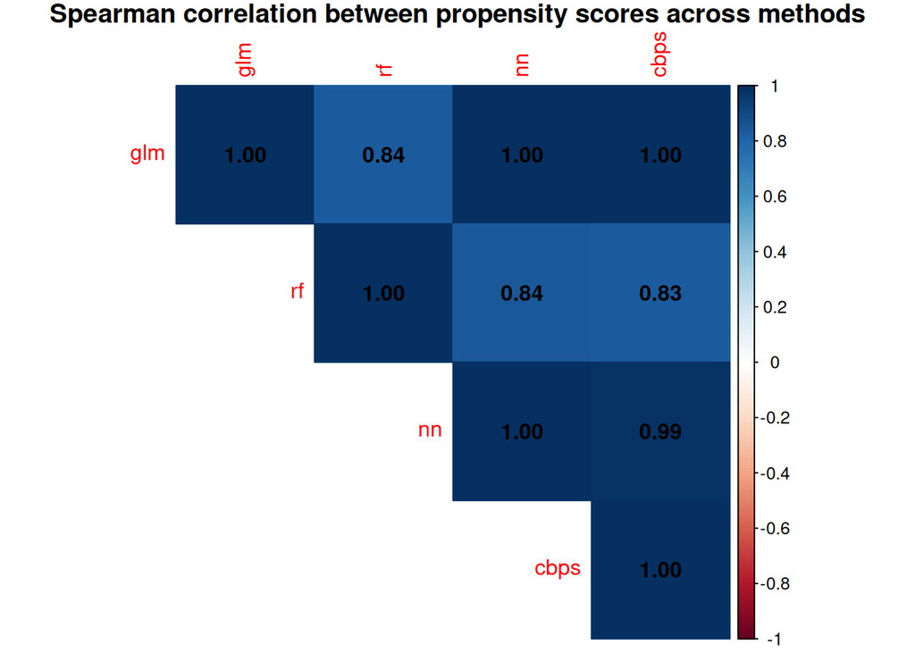

```r
corrplot(cor.matrix.spearman, method = "color", type = "upper", addCoef.col = "black",
         title = "Spearman correlation between propensity scores across methods", mar = c(0,0,1,0))
```

These correlation results reveal a clear pattern: the glm, NN, and CBPS propensity scores are all very highly correlated with each other (Pearson/Spearman both approximately 0.98–0.99), while RF stands notably apart, correlating with the other three at only 0.83–0.84. Note that both Pearson and Spearman agree with each other everywhere, so this isn’t a scale-vs-ranking artifact, rather the RF genuinely ranks patients differently compared to the other models, not just on a different numeric scale. Importantly, this is consistent with our earlier reasoning about the models their functional forms: glm, NN, and CBPS all model treatment as some smooth, additive function of the covariates, while RF’s completely different threshold-based, interaction-capturing splits produce a very different picture of who’s likely treated. This divergence here is in correspondance with RF’s comparatively worse SMD performance throughout our analysis; the model that thinks differently about the data is also the one that balances covariates least well, suggesting its threshold-based reasoning, whatever its clinical plausibility, isn’t capturing the confounding structure as effectively as the smoother models are.

## Variable importance

To further probe this interesting difference in propensity value prediction strategies, we want to find out why and how each approach determines who gets treated. To do this, we will compare the variable importance of the GLM (our preferred model) and RF propensity prediction models.

For the glm we cannot simply compare the raw coefficients, because a coefficient is per unit of its variable (one year of age versus one point of APACHE score versus a 0/1 indicator), so instead we use the absolute z-value (coefficient divided by its standard error), which is scale-free and is exactly what the p-value in summary(psmodel) is based on. For the forest we use both the mean decrease in Gini impurity, i.e. how much splitting on a variable improved the purity of the treated/untreated mix, summed over every split in every tree, and the permutation importance which randomly permutes the values of a variables (removing any statisticaly relationship with the outcome) and then computes the decrease in accuracy. We do this because one caveat has to be kept in mind is that Gini importance is biased towards continuous variables, because a variable like meanbp1 or age offers a tree hundreds of candidate cutoffs whereas a 0/1 indicator like dnr1 offers exactly one, so the continuous variable has more possibilities to create an optimal split (and therefore be important), so the forest will naturally rank the continuous physiological measurements above the binary history and category variables. Lastly, since the two measures are on completely different scales, so we compare ranks rather than values.

```r
print("===================================================")
```

```
## [1] "==================================================="
```

```r
set.seed(42)
glm.abs.z <- abs(summary(psmodel)$coefficients[-1, "z value"])  # [-1] drops the intercept
imp.all   <- importance(rf.model)
rf.gini   <- imp.all[, "MeanDecreaseGini"]
rf.perm   <- imp.all[, "MeanDecreaseAccuracy"]

importance.comparison <- data.frame(
  glm.abs.z = round(glm.abs.z[xvars], 2),
  rf.gini   = round(rf.gini[xvars], 1),
  rf.perm   = round(rf.perm[xvars], 2)
)

importance.comparison$glm.rank      <- rank(-importance.comparison$glm.abs.z)  # rank 1 = most important
importance.comparison$rf.gini.rank  <- rank(-importance.comparison$rf.gini)
importance.comparison$rf.perm.rank  <- rank(-importance.comparison$rf.perm)

print(importance.comparison[order(importance.comparison$rf.gini.rank), ])
```

```
##                 glm.abs.z rf.gini rf.perm glm.rank rf.gini.rank rf.perm.rank
## aps1                 8.08   123.9   22.66      2.0          1.0            1
## meanbp1              7.88   122.8   20.19      3.0          2.0            2
## crea1                1.11   109.0   19.71     30.0          3.0            3
## wtkilo1              6.23   100.6   11.34      5.5          4.0           12
## hema1                4.15   100.0   18.06     13.0          5.0            4
## age                  0.44    90.6   14.30     38.0          6.0            7
## wblc1                0.67    81.3    5.23     34.5          7.0           32
## paco21               5.76    78.4   13.27      7.0          8.0            8
## alb1                 2.26    77.7   17.87     24.0          9.0            5
## ph1                  3.19    76.6   11.35     18.0         10.0           11
## das2d3pc             1.03    74.8    8.75     32.0         11.0           20
## bili1                0.50    72.6   11.80     36.0         12.0           10
## temp1                0.46    69.9    4.54     37.0         13.0           33
## pot1                 5.27    68.8    5.89      9.0         14.0           29
## edu                  3.17    57.2    1.39     19.0         15.0           40
## scoma1               0.67    40.2    9.65     34.5         16.0           17
## card                 8.88    38.1   16.06      1.0         17.0            6
## resp                 2.64    22.9   11.29     21.0         18.0           13
## seps                 2.72    18.8    9.41     20.0         19.0           19
## dnr1                 6.41    16.8    8.20      4.0         20.0           21
## transhx              5.42    15.8    7.16      8.0         21.0           23
## malighx              3.31    14.6    6.57     17.0         22.0           26
## chrpulhx             2.40    14.2    7.61     23.0         23.0           22
## gastr                4.77    13.7    9.53     10.0         24.0           18
## cardiohx             1.10    13.3    5.79     31.0         25.0           30
## ARF                  2.52    13.0    3.76     22.0         26.0           37
## immunhx              0.21    12.6    1.62     39.0         27.0           39
## Coma                 4.70    11.8   10.66     11.0         28.0           15
## chfhx                0.02    11.7    6.58     40.0         29.0           25
## Cirrhosis            6.23    10.9   13.09      5.5         30.0            9
## dementhx             4.14    10.8    6.04     14.0         31.0           28
## CHF                  0.73    10.0   10.85     33.0         32.0           14
## psychhx              3.67     9.5    4.02     16.0         33.0           36
## liverhx              1.33     9.4   10.35     29.0         34.5           16
## hema                 3.86     9.4    6.43     15.0         34.5           27
## renal                2.04     8.1    5.64     26.0         36.0           31
## MOSF.Malignancy      1.90     7.6    2.67     27.0         37.0           38
## renalhx              2.13     6.5    4.12     25.0         38.0           35
## trauma               4.38     5.6    6.88     12.0         39.0           24
## Lung.Cancer          1.63     1.7    4.31     28.0         40.0           34
```

```r
sprintf("Spearman correlation, glm vs RF Gini: %.2f",
        cor(importance.comparison$glm.abs.z, importance.comparison$rf.gini, method = "spearman"))
```

```
## [1] "Spearman correlation, glm vs RF Gini: 0.14"
```

```r
sprintf("Spearman correlation, glm vs RF permutation: %.2f",
        cor(importance.comparison$glm.abs.z, importance.comparison$rf.perm, method = "spearman"))
```

```
## [1] "Spearman correlation, glm vs RF permutation: 0.33"
```

```r
sprintf("Spearman correlation, RF Gini vs RF permutation: %.2f",
        cor(importance.comparison$rf.gini, importance.comparison$rf.perm, method = "spearman"))
```

```
## [1] "Spearman correlation, RF Gini vs RF permutation: 0.61"
```

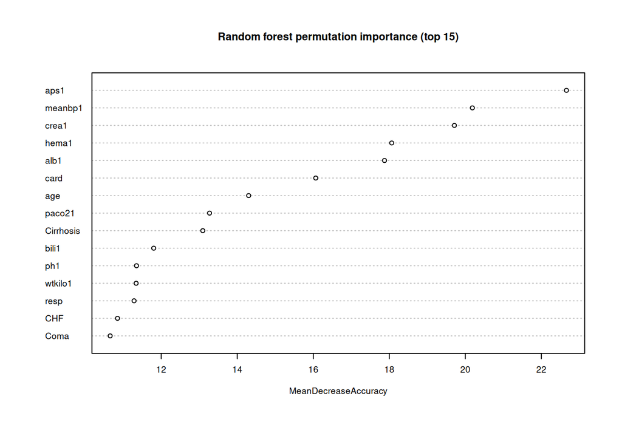

```r
varImpPlot(rf.model, n.var = 15, type = 1,
           main = "Random forest permutation importance (top 15)", cex = 0.6)
```

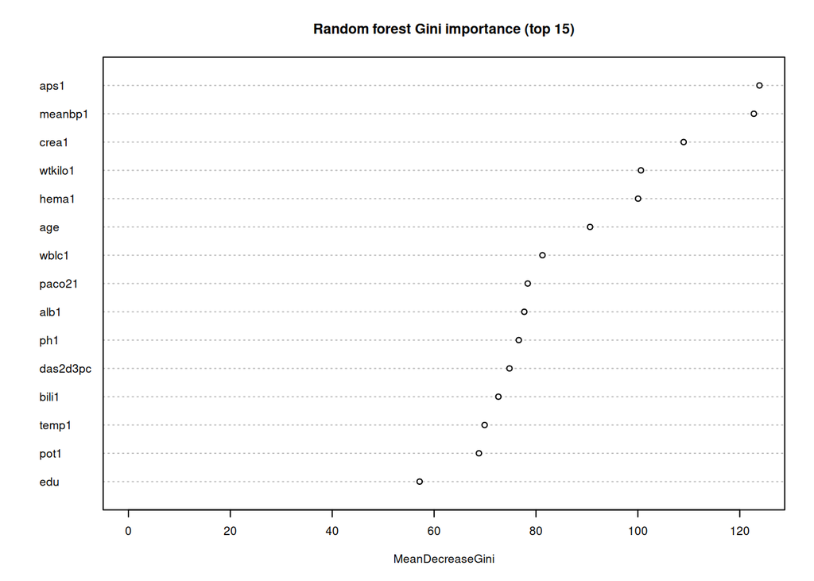

```r
varImpPlot(rf.model, n.var = 15, type = 2,
           main = "Random forest Gini importance (top 15)", cex = 0.6)
```

```r
print("===================================================")
```

```
## [1] "==================================================="
```

The rank correlation tells us to what degree the two models look at the same variables: a value near 1 would mean they weigh the covariates in the same order as predictor, a value near 0 that their is no monotonic relationship between the ordering of the importance of the variables: knowing how important a variable is to glm gives you no information about how important it is to RF (and vice versa). A variable that the forest ranks high but the glm ranks low, and that is not simply continuous, is therefore the best candidate for a threshold or interaction effect that the additive glm cannot express. Since the balance after matching was nonetheless better for the GLM, whatever extra structure the forest picked up did not translate into a better propensity score, which is the same conclusion as before seen from the other side. In the results we can actually see a very interesting pattern. There are a few stand out disagreements (e.g. rea1 (creatinine): glm rank 30 (barely significant, z=1.11) vs. RF rank 3 (one of its top variables)) and a lot of moderate disagreements (e.g age: glm rank 38 (z=0.44, essentially not significant) vs. RF rank 6), resulting in a Spearman ranking correlation of only 0.14 for Gini and 0.33 for correlation. It initially sounds quite surprising that there is practically no correlation between the variable importance ranks, even though the propensity scores correlate at the much more significant 0.83. However, when looking closer we can see that the models agree on a small set of dominant predictors. For example, meanbp1 and aps1 both being in the top 1-3, having large z of approx. 8). These few dominant predictor dominate the predictions, which is enough to drive fairly high score correlation. Why certain variables are important for the RF model but not for the GLM (e.g. crea1 and age), can be because those variables do not correlate linearly with treatment, but once included in non-linar interactions or splits/thresholds, they can indeed become important. Lastly, it is notable that their is only a Spearman correlation of 0.61 between the RF Gini ranking and RF permutation ranking, indicating that the Gini importance was partly inflating the apparent RF/glm disagreement, likely due to its known bias toward continuous variables with many split points (as explained earlier). Once you switch to the less-biased permutation measure, RF and glm’s importance rankings converge somewhat, though still far from strong agreement (0.33 is still weak).

#Partial dependence plot To investigate why RF and glm disagreed sharply on dominant predictors for RF like crea1 and age (high RF importance, near-zero glm significance), we plotted partial dependence curves for both variables to try and probe/interpret the RF’s model structure. This holds all other covariates at their observed values while sweeping the variable in questions across a range of values, and averaging each model’s predicted propensity score. Both variables show visible nonlinear and threshold/step behavior in the RF, not the smooth trend a linear glm term would produce — confirming RF is genuinely capturing nonlinear structure the glm cannot express. This is a nice nuance on our earlier finding that RF balanced worse than GLM despite this hypothesis. RF’s threshold behavior is real, it just didn’t help matching. This is likely because it also produced a rougher, more separated score distribution (consistent with RF’s higher extreme-score counts and less correlated scores we saw before). So the intial “RF should balance better because it thinks like a clinician” hypothesis was right about the mechanism, but wrong about the practical payoff, which is a more interesting result, since it separates whether a model captures the expected structure from whether that structure helps the specific task of matching.

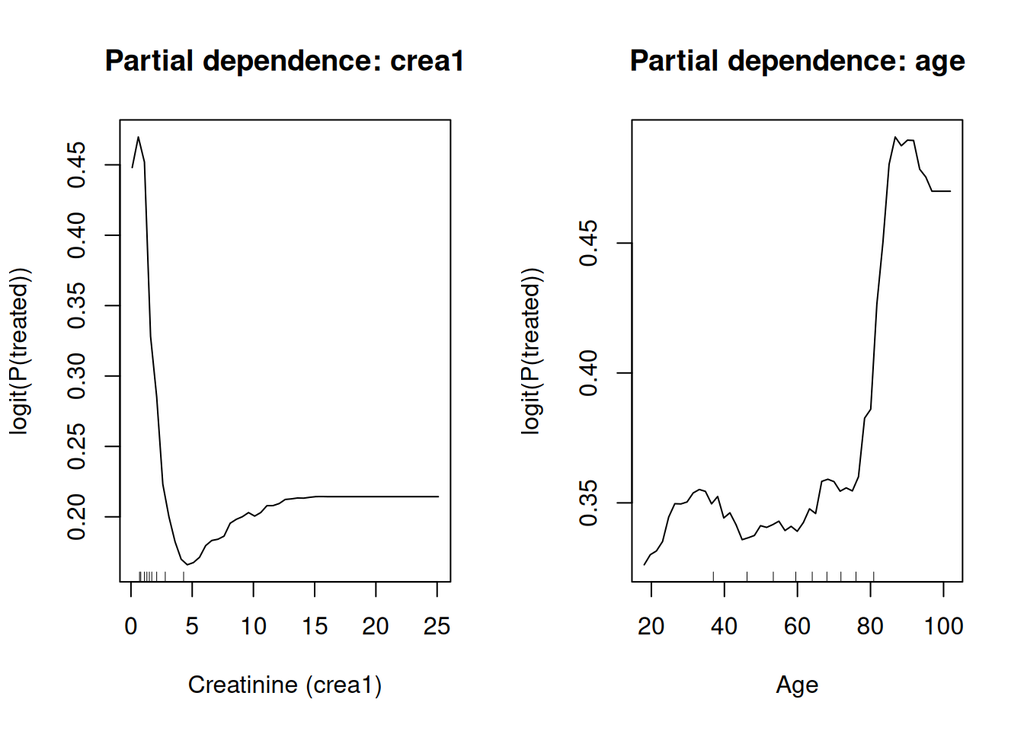

```r
par(mfrow = c(1, 2))

partialPlot(rf.model, pred.data = rf.data, x.var = "crea1",
            main = "Partial dependence: crea1", xlab = "Creatinine (crea1)", ylab = "logit(P(treated))")

partialPlot(rf.model, pred.data = rf.data, x.var = "age",
            main = "Partial dependence: age", xlab = "Age", ylab = "logit(P(treated))")
```

```r
par(mfrow = c(1, 1))
```

## Caliper width

Throughout the assignment we matched with a caliper of 0.2 standard deviations of the logit of the propensity score, which is the width recommended by Austin (2011), but we never checked whether that choice mattered, it was simply given to us by the instructors. The caliper is the knob that sets the bias-variance tradeoff of matching directly: a narrow caliper only accepts close matches, so the matched groups are well balanced (low bias), but more treated patients are left without a match, so the outcome effect estimate is based on fewer pairs (high variance) and, more subtly, on a different group of patients than the full treated population, as explained before. On the other hand, a wide caliper keeps nearly all treated patients but accepts poorer matches, so the imbalance creeps back in. Below we repeat the matching for a range of calipers, for all four propensity score models, and record the number of pairs, the balance and the resulting effect estimate given as the odds ratio from the GLM coefficient. Later, we perform a similar analysis for the greedy matching approach, but we do this seperately since it lives on an entirely different caliper scale as it is in 40D rather than 1D.

```r
calipers <- c(0.05, 0.1, 0.2, 0.5, 0.75, 1, 2)
logits.rf   <- logit(pmin(pmax(pscore.rf, 0.005), 0.995))
logits.nn   <- logit(pmin(pmax(pscore.nn, 0.005), 0.995))
logits.cbps <- logit(pmin(pmax(pscore.cbps, 0.005), 0.995))

caliper.comparison <- data.frame()

for (cal in calipers) {
  for (model in c("glm", "rf", "nn", "cbps")) {
    X.model <- switch(model,
                       glm  = logits,
                       rf   = logits.rf,
                       nn   = logits.nn,
                       cbps = logits.cbps)
    set.seed(42)
    mt <- Match(Tr = rhc.selected$treatment.swang, M = 1, X = X.model,
                replace = FALSE, Weight = 2, caliper = cal)
    md  <- rhc.selected[unlist(mt[c("index.treated", "index.control")]), ]
    smd <- ExtractSmd(CreateTableOne(vars = xvars, strata = "treatment.swang", data = md, test = FALSE))
    y.t <- md$outcome.died[md$treatment.swang == 1]
    y.c <- md$outcome.died[md$treatment.swang == 0]

    gmodel.cal <- glm(outcome.died ~ treatment.swang, family = binomial, data = md)
    coef.summary <- summary(gmodel.cal)$coefficients

    caliper.comparison <- rbind(caliper.comparison, data.frame(
      model          = model,
      caliper        = cal,
      matched.pairs  = length(mt$index.treated),
      max.smd        = round(max(smd), 3),
      n.smd.over.0.1 = sum(smd > 0.1),
      mean.diff      = round(mean(y.t - y.c), 3),
      OR             = round(exp(coef.summary["treatment.swang", "Estimate"]), 3),
      p.value        = signif(coef.summary["treatment.swang", "Pr(>|z|)"], 3)))
  }
}
print(caliper.comparison, row.names = FALSE)
```

```
##  model caliper matched.pairs max.smd n.smd.over.0.1 mean.diff    OR  p.value
##    glm    0.05          1715   0.040              0     0.062 1.313 1.51e-04
##     rf    0.05          1632   0.109              3     0.029 1.138 8.14e-02
##     nn    0.05          1725   0.034              0     0.060 1.303 2.29e-04
##   cbps    0.05          1718   0.059              0     0.079 1.414 1.42e-06
##    glm    0.10          1721   0.050              0     0.071 1.366 1.37e-05
##     rf    0.10          1641   0.110              3     0.029 1.137 8.22e-02
##     nn    0.10          1728   0.045              0     0.059 1.299 2.67e-04
##   cbps    0.10          1723   0.060              0     0.070 1.362 1.61e-05
##    glm    0.20          1734   0.035              0     0.061 1.305 1.89e-04
##     rf    0.20          1660   0.115              2     0.029 1.139 7.70e-02
##     nn    0.20          1740   0.040              0     0.057 1.287 4.20e-04
##   cbps    0.20          1733   0.058              0     0.066 1.339 4.36e-05
##    glm    0.50          1811   0.041              0     0.055 1.273 5.57e-04
##     rf    0.50          1751   0.122              2     0.033 1.158 4.12e-02
##     nn    0.50          1832   0.051              0     0.053 1.265 7.43e-04
##   cbps    0.50          1804   0.059              0     0.064 1.324 6.04e-05
##    glm    0.75          1887   0.050              0     0.054 1.266 5.65e-04
##     rf    0.75          1851   0.125              3     0.034 1.166 2.81e-02
##     nn    0.75          1930   0.077              0     0.052 1.261 6.37e-04
##   cbps    0.75          1889   0.074              0     0.066 1.334 2.45e-05
##    glm    1.00          1962   0.088              0     0.055 1.276 2.95e-04
##     rf    1.00          1951   0.127              6     0.026 1.125 8.34e-02
##     nn    1.00          2008   0.107              1     0.052 1.258 5.57e-04
##   cbps    1.00          1961   0.113              1     0.058 1.289 1.55e-04
##    glm    2.00          2150   0.200              4     0.057 1.284 9.60e-05
##     rf    2.00          2161   0.172             10     0.031 1.149 3.10e-02
##     nn    2.00          2183   0.208              5     0.048 1.238 8.27e-04
##   cbps    2.00          2153   0.215              4     0.065 1.330 8.16e-06
```

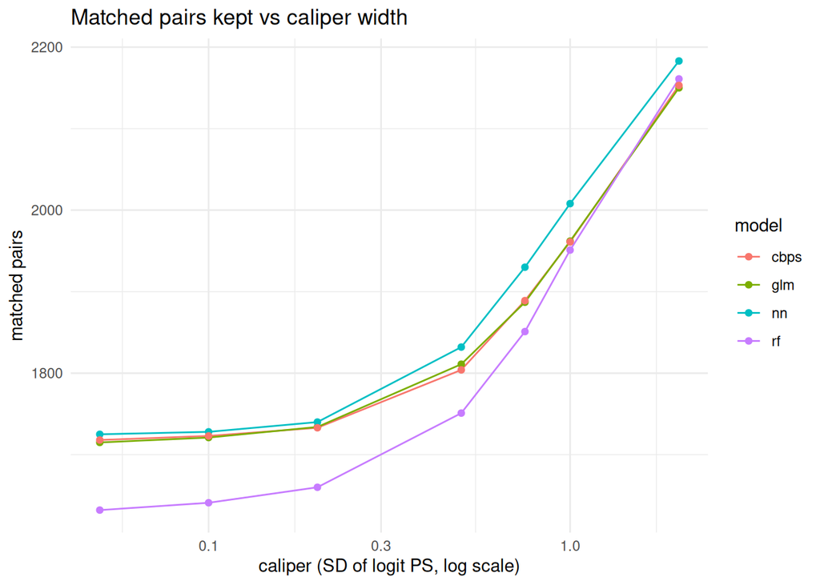

```r
ggplot(caliper.comparison, aes(x = caliper, y = matched.pairs, colour = model)) +
  geom_line() + geom_point() + scale_x_log10() +
  labs(x = "caliper (SD of logit PS, log scale)", y = "matched pairs", title = "Matched pairs kept vs caliper width") +
  theme_minimal()
```

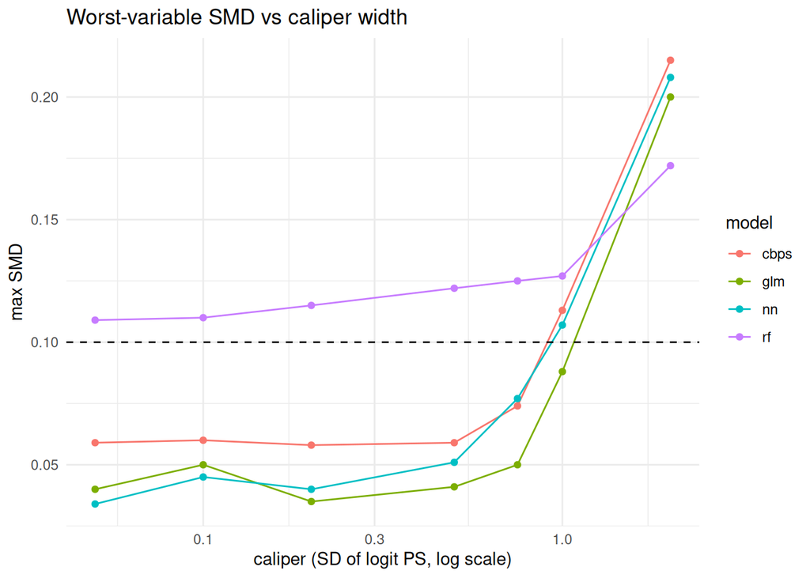

```r
ggplot(caliper.comparison, aes(x = caliper, y = max.smd, colour = model)) +
  geom_line() + geom_point() + scale_x_log10() +
  geom_hline(yintercept = 0.1, linetype = "dashed") +
  labs(x = "caliper (SD of logit PS, log scale)", y = "max SMD", title = "Worst-variable SMD vs caliper width") +
  theme_minimal()
```

Regarding the greedy matching with the Mahalanobis distance; we already observed that it obtains 0 matches using a caliper due to the matching happening in 40D. Moreover, it is interpreted as the variation in each covariate in standardized units of that covariate, rather than the variation in the logit of a predicted scalar - the caliper means very different things in each of the cases. As a result, the caliper range needsa completely different variation scale and shouldn’t be compared directly with the other calipers, which is why we gave it it’s own brief analysis here.

```r
calipers.maha <- c(0.5, 1, 2, 5, 10, 20)  # far larger, since caliper applies per-covariate across 40 dimensions
maha.comparison <- data.frame()

for (cal in calipers.maha) {
  set.seed(42)
  mt <- Match(Tr = rhc.selected$treatment.swang, M = 1, X = as.matrix(rhc.selected[xvars]),
              replace = FALSE, Weight = 2, caliper = cal)

  if (!is.list(mt) || is.null(mt$index.treated)) {
    maha.comparison <- rbind(maha.comparison, data.frame(
      caliper = cal, matched.pairs = 0, max.smd = NA, n.smd.over.0.1 = NA, mean.diff = NA, OR = NA))
    next
  }

  md  <- rhc.selected[unlist(mt[c("index.treated", "index.control")]), ]
  smd <- ExtractSmd(CreateTableOne(vars = xvars, strata = "treatment.swang", data = md, test = FALSE))
  y.t <- md$outcome.died[md$treatment.swang == 1]
  y.c <- md$outcome.died[md$treatment.swang == 0]

  gmodel.cal <- glm(outcome.died ~ treatment.swang, family = binomial, data = md)
  coef.summary <- summary(gmodel.cal)$coefficients

  maha.comparison <- rbind(maha.comparison, data.frame(
    caliper        = cal,
    matched.pairs  = length(mt$index.treated),
    max.smd        = round(max(smd), 3),
    n.smd.over.0.1 = sum(smd > 0.1),
    mean.diff      = round(mean(y.t - y.c), 3),
    OR             = round(exp(coef.summary["treatment.swang", "Estimate"]), 3),
    p.value        = signif(coef.summary["treatment.swang", "Pr(>|z|)"], 3)))
}
print(maha.comparison, row.names = FALSE)
```

```
##  caliper matched.pairs max.smd n.smd.over.0.1 mean.diff    OR  p.value
##      0.5             2   1.333             13    -0.500 0.000 9.98e-01
##      1.0            58   0.264              8    -0.017 0.932 8.52e-01
##      2.0           694   0.285              7     0.079 1.382 2.91e-03
##      5.0          2165   0.498             16     0.095 1.507 1.06e-10
##     10.0          2167   0.502             16     0.094 1.504 1.31e-10
##     20.0          2183   0.500             16     0.091 1.484 4.32e-10
```

In the results table above, we can see a few interesting results. First, we see that as the caliper is increased significantly, in range of 5+, we do get a significant amount of matches, meaning that in that case most treated patients do find at least 1 (unmatched) control where each of the 40 variables differ by no more than 5 standardized units. Notably, the p-values here also get small (in the range of e-10), and the odds ratio indicates, again, a positive result (death chances increase with treatment), though the OR is a lot larger than before: approximately 1.5 here whereas the other model were in the range of 1.1-1.3. However, we also observe that the number of variables with SMD above 0.1 is still 16 (which is more than at smaller calipers since the matches allowed are worse, per the bias-variance tradeoff discussed above), and the max smd stays around 0.5, which raises significant concerns regarding confounding. Considering this, even at higher calipers, getting larger amounts of matches, we still prefer the other models as the balancing of the covariates between the two groups is significantly better for those methods, allowing us to place significantly more trust in our obtained results.

# Inverse probability weighting (IPW)

Throughout this entire report, we simply assumed the matching strategy given to us at the start. However, maybe this is not the optimal strategy to use and do other strategies achieve better or similar balancing quality, while preserving more matched pairs. As such, as a last experiment, we try out an alternative to matching: inverse probability weighting. Here, all treated observations get a weight of 1, while the untreated observations get weighted by their odds of being treated (odds of the propensity score). Thus, untreated patients who look very likely to be treated are upweighted, since they are likely rare among the untreated, while untreated patients which don’t look like treated pateints get downweighted, since they are common among this group. As a result, the weighted distribution of covariates of the untreated group is reshaped to look very similar to that of the treated group, (hopefully) achieving balancing of each covariates, the same result that matching tries to achieve. Then, all patients are used in a weighted manner in the downstream outcome effect analysis. This allows us to isolate and compare each model’s own balancing quality, without relying on the matching step to drop bad quality matches.

```r
compute_att_weights <- function(ps, treatment) {
  ifelse(treatment == 1, 1, ps / (1 - ps))
}

pscores.list <- list(
  glm  = pscore,
  rf   = pscore.rf,
  nn   = pscore.nn,
  cbps = pscore.cbps
)

ipw.comparison <- data.frame()

for (name in names(pscores.list)) {
  ps.c <- pmin(pmax(pscores.list[[name]], 0.005), 0.995)
  w <- compute_att_weights(ps.c, rhc.selected$treatment.swang)

  design.w <- svydesign(ids = ~1, data = rhc.selected[, c(xvars, "treatment.swang", "outcome.died")], weights = ~w)

  # Balance check as before
  tab.weighted <- svyCreateTableOne(vars = xvars, strata = "treatment.swang", data = design.w, test = FALSE)
  smd.weighted <- ExtractSmd(tab.weighted)

  # Test treatment effect on outcome, using the same weights design
  m <- svyglm(outcome.died ~ treatment.swang, family = quasibinomial, design = design.w)
  cf <- summary(m)$coefficients

  ipw.comparison <- rbind(ipw.comparison, data.frame(
    model           = name,
    max.smd         = round(max(smd.weighted), 3),
    n.smd.under.0.1 = sum(smd.weighted < 0.1),
    n.smd.0.1.0.2   = sum(smd.weighted >= 0.1 & smd.weighted < 0.2),
    n.smd.over.0.2  = sum(smd.weighted > 0.2),
    max.weight      = round(max(w), 1),
    OR              = round(exp(cf["treatment.swang", "Estimate"]), 3),
    p.value         = signif(cf["treatment.swang", "Pr(>|t|)"], 3)))
}
print(ipw.comparison, row.names = FALSE)
```

```
##  model max.smd n.smd.under.0.1 n.smd.0.1.0.2 n.smd.over.0.2 max.weight    OR
##    glm   0.100              39             1              0       20.2 1.299
##     rf   0.110              38             2              0        5.0 1.174
##     nn   0.082              40             0              0        4.8 1.285
##   cbps   0.002              40             0              0       11.1 1.352
##   p.value
##  3.39e-04
##  1.50e-02
##  2.12e-04
##  1.51e-05
```

# Final Conclusions

In conclusion, after deep and thoughtful analysis of different propensity prediction models used for matching, including probing of various properties of them, and looking at an alternatives to the standard matching architecture we were given initially, we arrive at one most favourable approach. The intial GLM (logistic regression) propensity prediction model is the preferred model of choice as it: 1. produced the best overall balancing of each covariate across the treated and non-treated groups, and 2. it is the more simplistic and consequently interpretable model, as we can look at its standardized coefficients to directly get an accurate idea of the role each variable plays in its predictions, as opposed to, for example, the neural network whose weights are much more a blackbox. Moreover, we observed that matching with a slightly better caliper (approximately 0.75 standardized units) would allow for more matches, and consequently more power and less noisy estimates in the downstream outcome analysis, while hardly reducing the balancing is the best balancing approach, and preferred over direct inverse probability weighting. This preferred approach led to an odds ratio of 1.266 with a p-value of 5.65e-04, suggesting that their is enough evidence to conclude that RHC treatment increase the odds of dying, assuming the ignorability assumption holds.

#References Austin, P. C. (2011). Optimal caliper widths for propensity-score matching when estimating differences in means and differences in proportions in observational studies. Pharmaceutical Statistics, 10(2), 150-161.

Imai, K., & Ratkovic, M. (2014). Covariate balancing propensity score. Journal of the Royal Statistical Society Series B: Statistical Methodology, 76(1), 243-263.